# Introduction to matplotlib

Contains material from:

- The matplotlib tutorial and user guide at http://matplotlib.org/.

> Panos Louridas, Associate Professor  
> Department of Management Science and Technology  
> Athens University of Economics and Business  
> louridas@aueb.gr
- matplotlib is the base visualization library in Python.
- It is highly customizable and can be used to produce pretty much any kind of graph.
- At the same time it may require a lot of work to produce graphs that look nice and customization may require fiddling with lots of little details.
- Everything in matplotlib is organized in a hierarchy.
- At the top of the hierarchy is the matplotlib "state-machine environment" which is provided by the `matplotlib.pyplot` module.
- At this level, simple functions are used to add plot elements (lines, images, text, etc.) to the current axes in the current figure.
- The next level down in the hierarchy is the first level of the object-oriented interface, in which `pyplot` is used only for a few functions such as figure creation, and the user explicitly creates and keeps track of the figure and axes objects.
- At this level, the user uses `pyplot` to create figures, and through those figures, one or more axes objects can be created. These axes objects are then used for most plotting actions.
- For even more control – which is essential for things like embedding matplotlib plots in GUI applications – the pyplot level may be dropped completely, leaving a purely object-oriented approach.

[figure not shown]

## Figure

- The whole figure (marked as the outer red box).
- The figure keeps track of all the child `Axes`, a smattering of "special" artists (titles, figure legends, etc), and the canvas.
- A figure can have any number of Axes, but to be useful it should have at least one.
- The easiest way to create a new figure is with pyplot:

```
fig = plt.figure()  # an empty figure with no axes
fig, ax_lst = plt.subplots(2, 2)  # a figure with a 2x2 grid of Axes
```

## Axes

This is what you think of as "a plot", it is the region of the image with the data space (marked as the inner blue box).

- A given figure can contain many `Axes`, but a given `Axes` object can only be in one Figure.
- The `Axes` contains two (or three in the case of 3D) `Axis` objects (be aware of the difference between `Axes` and `Axis`).
- Each `Axes` has a title (set via `set_title()`), an x-label (set via `set_xlabel()`), and a y-label (set via `set_ylabel()`).

## Axis

- These are the number-line-like objects (circled in green).
- They take care of the data limits (the data limits can also be controlled via set via the `set_xlim()` and `set_ylim()` `Axes` methods).
- They also take care of setting the graph limits and generating the ticks (the marks on the axis) and ticklabels (strings labeling the ticks).
- The location of the ticks is determined by a `Locator` object and the ticklabel strings are formatted by a `Formatter`.
- The combination of the correct `Locator` and `Formatter` gives very fine control over the tick locations and labels.

## Artist

- Basically everything you can see on the figure is an artist (even the `Figure`, `Axes`, and `Axis` objects).
- This includes `Text` objects, `Line2D` objects, `collection` objects, `Patch` objects...
- When the figure is rendered, all of the artists are drawn to the canvas.
- Most `Artists` are tied to an `Axes`; such an Artist cannot be shared by multiple `Axes`, or moved from one to another.

## Working with `pyplot`

- `pyplot` allows us to add plot elements without having to access `Figure` and `Axes` objects.

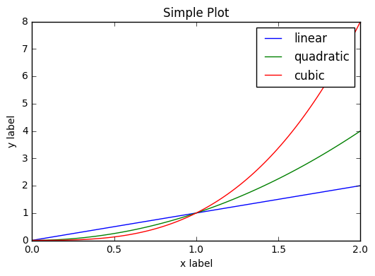

```python
import matplotlib.pyplot as plt
import numpy as np

%matplotlib inline

x = np.linspace(0, 2, 100)

plt.plot(x, x, label='linear')
plt.plot(x, x**2, label='quadratic')
plt.plot(x, x**3, label='cubic')

plt.xlabel('x label')
plt.ylabel('y label')

plt.title("Simple Plot")

plt.legend()
```

## Working with figures and axes

- The code above is equivalent to the code below, where we do get the current `Figure`, then the current `Axes`, and then we draw on these `Axes`.

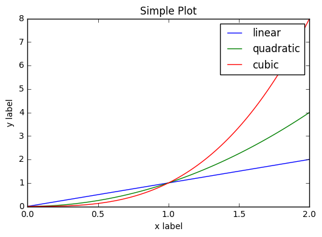

```python
fig = plt.figure()  # an empty figure with no axes

axes = fig.gca()
axes.plot(x, x, label='linear')

axes.plot(x, x**2, label='quadratic')
axes.plot(x, x**3, label='cubic')

axes.set_xlabel('x label')
axes.set_ylabel('y label')

axes.set_title("Simple Plot")

axes.legend()
```

# matplotlib styles

- The general appearance of matplotlib plots is defined in terms of *styles*.
- There are a number of different styles already available in the `styles` package.

```python
print(plt.style.available)
```

```
['seaborn-notebook', 'seaborn-dark-palette', 'seaborn-white', 'seaborn-bright', 'ggplot', 'seaborn-pastel', 'seaborn-whitegrid', 'seaborn-deep', 'seaborn-poster', 'fivethirtyeight', 'seaborn-ticks', 'bmh', 'seaborn-talk', 'seaborn-paper', 'seaborn-dark', 'classic', 'dark_background', 'seaborn-colorb…
```

- A popular style is `ggplot`, which emulates the look and feel of R's ggplot package.

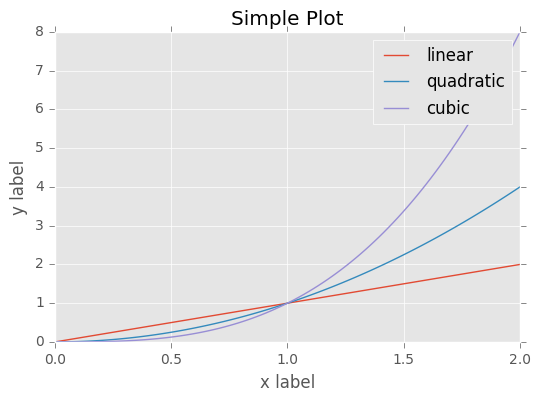

```python
plt.style.use('ggplot')

x = np.linspace(0, 2, 100)

plt.plot(x, x, label='linear')
plt.plot(x, x**2, label='quadratic')
plt.plot(x, x**3, label='cubic')

plt.xlabel('x label')
plt.ylabel('y label')

plt.title("Simple Plot")

plt.legend()
```

# Working with Legends (and Multiple Plots)

- As everything else in matplotlib, legends are highly customizable.
- In the above example, there is a slight problem in that the legend overlaps with part of the lines.
- The location of the legend can be set with the `loc` parameter, which can taken the following values.

| Location String | Location Code |
| --- | --- |
| 'best' | 0 |
| 'upper right' | 1 |
| 'upper left' | 2 |
| 'lower left' | 3 |
| 'lower right' | 4 |
| 'right' | 5 |
| 'center left' | 6 |
| 'center right' | 7 |
| 'lower center' | 8 |
| 'upper center' | 9 |
| 'center' | 10 |

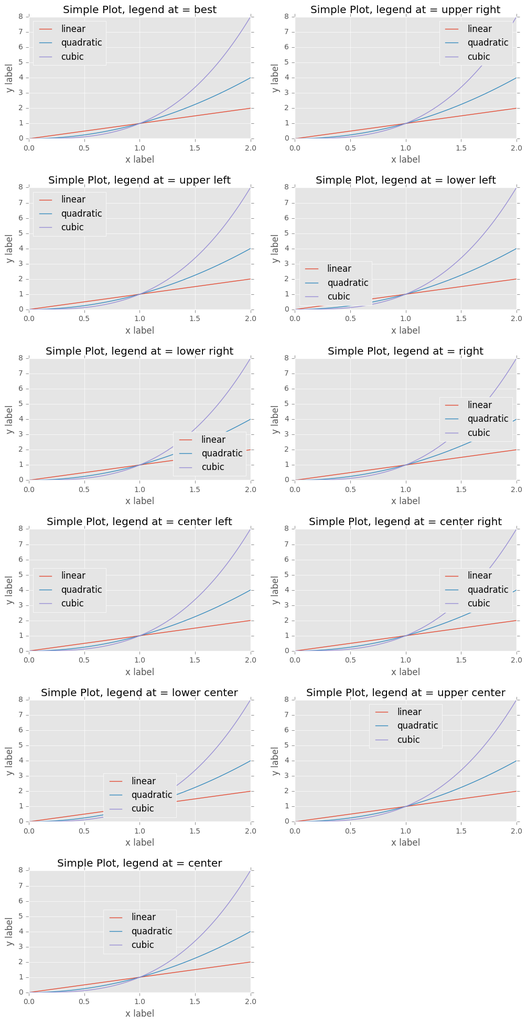

```python
legend_loc_str = [
    'best',
    'upper right',
    'upper left',
    'lower left',
    'lower right',
    'right',
    'center left',
    'center right',
    'lower center',
    'upper center',
    'center'
]

plt.figure(figsize=(12, 24))
plt.subplots_adjust(hspace=0.4)

x = np.linspace(0, 2, 100)

for loc in range(0, 11):
    plt.subplot(6, 2, loc + 1)
    plt.plot(x, x, label='linear')
    plt.plot(x, x**2, label='quadratic')
    plt.plot(x, x**3, label='cubic')

    plt.xlabel('x label')
    plt.ylabel('y label')

    plt.title("Simple Plot, legend at = " + legend_loc_str[loc])

    plt.legend(loc=loc)
```

- As we said before, `pyplot` is just a wrapper around figures and axes.
- That means that the above code is actually equivalent to the one below.

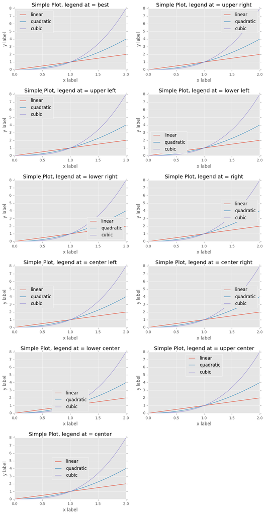

```python
figure = plt.figure(figsize=(12, 24))
figure.subplots_adjust(hspace=0.4)

x = np.linspace(0, 2, 100)

for loc in range(0, 11):
    ax = figure.add_subplot(6, 2, loc + 1)
    ax.plot(x, x, label='linear')
    ax.plot(x, x**2, label='quadratic')
    ax.plot(x, x**3, label='cubic')

    ax.set_xlabel('x label')
    ax.set_ylabel('y label')

    ax.set_title("Simple Plot, legend at = " + legend_loc_str[loc])

    ax.legend(loc=loc)
```

# Colors and Colormaps

- Commands that take color arguments can use several formats to specify the colors. There are eight built-in colors, for which you can use a single letter.
  - `b`: blue
  - `g`: green
  - `r`: red
  - `c`: cyan
  - `m`: magenta
  - `y`: yellow
  - `k`: black
  - `w`: white

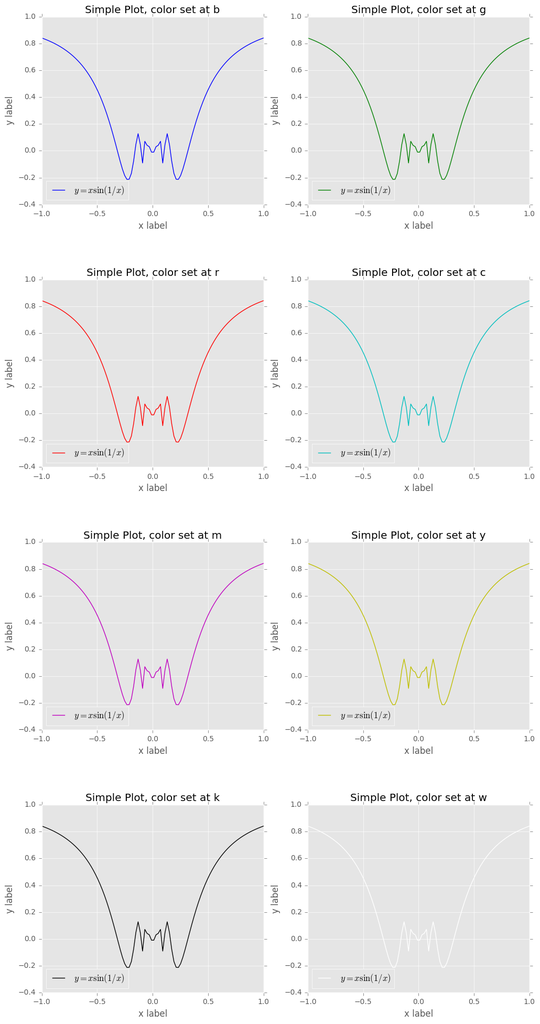

```python
color = [
    'b',
    'g',
    'r',
    'c',
    'm',
    'y',
    'k',
    'w'
]

figure = plt.figure(figsize=(12, 24))
figure.subplots_adjust(hspace=0.4)

x = np.linspace(-1, 1, 100)
y = x * np.sin(1 / x)

for loc in range(0, 8):
    ax = figure.add_subplot(4, 2, loc + 1)
    ax.plot(x, y, color=color[loc], label=r'$y = x \sin(1/x)$')

    ax.set_xlabel('x label')
    ax.set_ylabel('y label')

    ax.set_title("Simple Plot, color set at " + color[loc])

    ax.legend(loc='best')
```

- Other ways to specify colors:
  - Gray shades can be given as a string encoding a float in the 0-1 range, e.g.: `color = '0.75'`.
  - Colors can be specified using an html hex string, as in: `color = '#eeefff'`
  - Colors can also be specified by passing an R, G, B tuple, where each of R, G, B are in the range `[0,1]`.
  - Finally, legal html names for colors, like 'red', 'burlywood' and 'chartreuse' are supported.
- Colors can also be selected from *colormaps*.
- There are three classes of colormaps:
  - Sequential: change in lightness and often saturation of color incrementally, often using a single hue; should be used for representing information that has ordering.
  - Diverging: change in lightness and possibly saturation of two different colors that meet in the middle at an unsaturated color; should be used when the information being plotted has a critical middle value, such as topography or when the data deviates around zero.
  - Qualitative: often are miscellaneous colors; should be used to represent information which does not have ordering or relationships.
- The following `cmaps` list contains tuples of the form `('Colormap Category', [colormap_1, colormap_2, colormap_3])`.

```python
cmaps = [('Perceptually Uniform Sequential',
          ['viridis', 'inferno', 'plasma', 'magma']),
         ('Sequential',
          ['Blues', 'BuGn', 'BuPu',
           'GnBu', 'Greens', 'Greys', 'Oranges', 'OrRd',
           'PuBu', 'PuBuGn', 'PuRd', 'Purples', 'RdPu',
           'Reds', 'YlGn', 'YlGnBu', 'YlOrBr', 'YlOrRd']),
         ('Sequential (2)',
          ['afmhot', 'autumn', 'bone', 'cool',
           'copper', 'gist_heat', 'gray', 'hot',
           'pink', 'spring', 'summer', 'winter']),
         ('Diverging',
          ['BrBG', 'bwr', 'coolwarm', 'PiYG', 'PRGn', 'PuOr',
           'RdBu', 'RdGy', 'RdYlBu', 'RdYlGn', 'Spectral',
           'seismic']),
         ('Qualitative',
          ['Accent', 'Dark2', 'Paired', 'Pastel1',
           'Pastel2', 'Set1', 'Set2', 'Set3']),
         ('Miscellaneous',
          ['gist_earth', 'terrain', 'ocean', 'gist_stern',
           'brg', 'CMRmap', 'cubehelix',
           'gnuplot', 'gnuplot2', 'gist_ncar',
           'nipy_spectral', 'jet', 'rainbow',
           'gist_rainbow', 'hsv', 'flag', 'prism'])]
```

- To display them, we'll use a gradient array for each colormap.
- Each gradient array will contain two 256 equally-spaced points in the values from 0 to 1 (inclusive).
- That's because colormaps also have a 256-value resolution.
- We'll use the `numpy.vstack` function that stacks arrays vertically (row wise).

```python
gradient = np.linspace(0, 1, 256)
gradient = np.vstack((gradient, gradient))
```

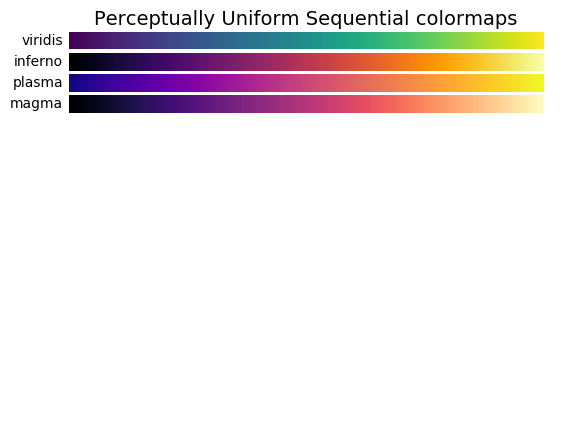

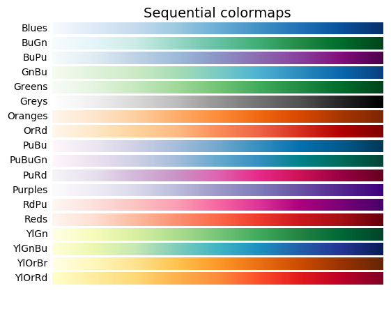

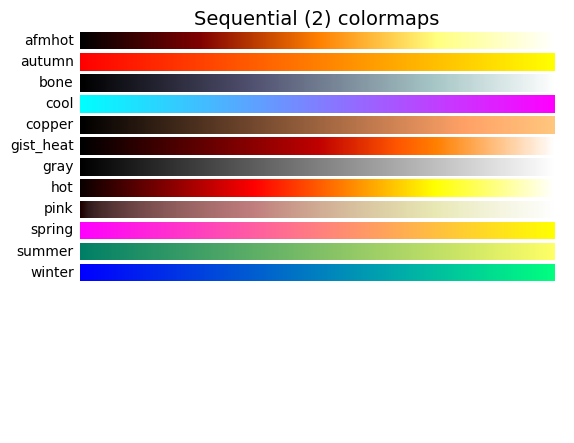

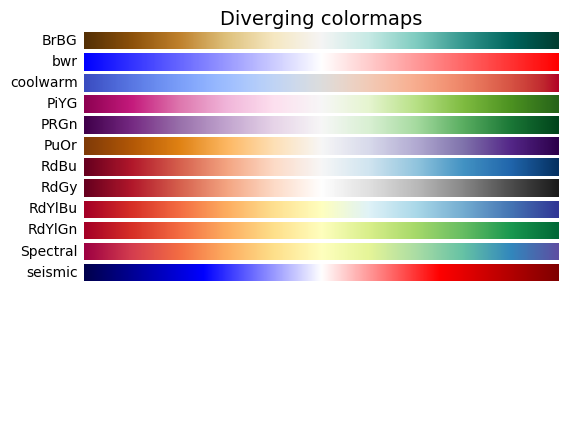

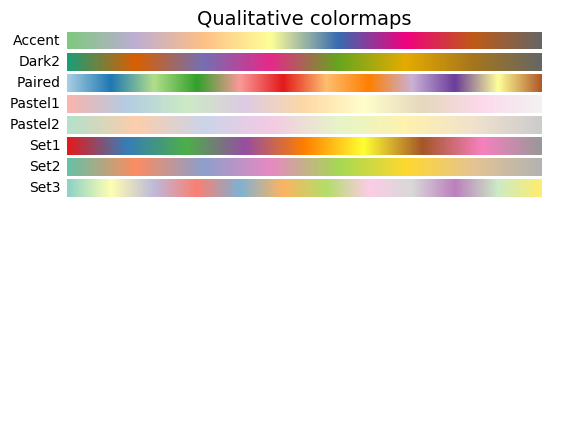

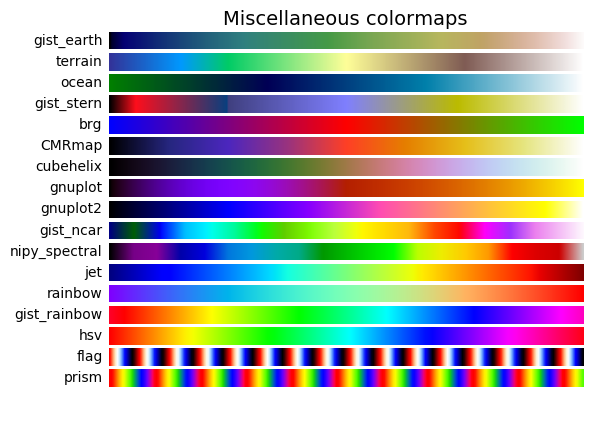

```python
nrows = max(len(cmap_list) for cmap_category, cmap_list in cmaps)

def plot_color_gradients(cmap_category, cmap_list):
    fig, axes = plt.subplots(nrows=nrows)
    fig.subplots_adjust(top=0.95, bottom=0.01, left=0.2, right=0.99)
    axes[0].set_title(cmap_category + ' colormaps', fontsize=14)

    for ax, name in zip(axes, cmap_list):
        ax.imshow(gradient, aspect='auto', cmap=plt.get_cmap(name))
        pos = list(ax.get_position().bounds)
        x_text = pos[0] - 0.01
        y_text = pos[1] + pos[3]/2.
        fig.text(x_text, y_text, name, va='center', ha='right', fontsize=10)

    # Turn off *all* ticks & spines, not just the ones with colormaps.
    for ax in axes:
        ax.set_axis_off()

for cmap_category, cmap_list in cmaps:
    plot_color_gradients(cmap_category, cmap_list)
```

# Creating a Correlation Plot with matplotlib

- A correlation plot shows, for a set of variables, the correlations between any pair of variables from the set.
- An informative correlation plot should show:
  - The correlation between each pair.
  - Whether the correlation is positive or negative.
  - Whether the correlation is statistically significant.
- We'll write a function that will draw such plots.
- The function will be called `corrplot` and will be called like: `corrplot(data, pvalues, labels)`.
  - `data` is the correlation matrix, a 2D numpy array containing the pairwise correlations between variables.
  - `pvalues` is a matrix containing the p-value for each corresponding correlation value.
  - `labels` is an array containing the variable names.

```python
import matplotlib.cm as cm
from matplotlib.patches import Ellipse

def corrplot(data, pvalues, labels):
    """Creates a correlation plot of the passed data.
    The function returns the plot which can then be shown with
    plot.show(), saved to a file with plot.savefig(), or manipulated
    in any other standard matplotlib way.
    data is the correlation matrix, a 2-D numpy array containing
    the pairwise correlations between variables;
    pvalues is a matrix containing the pvalue for each corresponding
    correlation value; if none it is assumed to be the zero matrix
    labels is an array containing the variable names
    """

    plt.figure(1)

    column_labels = labels
    row_labels = labels

    ax = plt.subplot(1, 1, 1, aspect='equal')

    width, height = data.shape
    num_cols, num_rows = width, height

    if pvalues is None:
        pvalues = np.zeros([num_rows, num_cols])

    shrink = 0.9

    poscm = cm.get_cmap('Blues')
    negcm = cm.get_cmap('Oranges')

    for x in range(width):
        for y in range(height):
            d = data[x, y]
            c = pvalues[x, y]
            rotate = -45 if d > 0 else +45
            clrmap = poscm if d >= 0 else negcm
            d_abs = np.abs(d)
            ellipse = Ellipse((x, y),
                              width=1 * shrink,
                              height=(shrink - d_abs*shrink),
                              angle=rotate)
            ellipse.set_edgecolor('black')
            ellipse.set_facecolor(clrmap(d_abs))
            if c > 0.05:
                ellipse.set_linestyle('dotted')
            ax.add_artist(ellipse)

    ax.set_xlim(-1, num_cols)
    ax.set_ylim(-1, num_rows)

    ax.xaxis.tick_top()
    xtickslocs = np.arange(len(row_labels))
    ax.set_xticks(xtickslocs)
    ax.set_xticklabels(row_labels, rotation=30, fontsize='small', ha='left')

    ax.invert_yaxis()
    ytickslocs = np.arange(len(row_labels))
    ax.set_yticks(ytickslocs)
    ax.set_yticklabels(column_labels, fontsize='small')

    return plt
```

- To check `corrplot` we'll use a dataset included with statsmodels.

```python
import statsmodels as sm

randhie = sm.datasets.randhie

randhie_df = randhie.load_pandas().data

print(randhie.TITLE)
print(randhie.NOTE)
print(randhie.SOURCE)
```

```
RAND Health Insurance Experiment Data
::

    Number of observations - 20,190
    Number of variables - 10
    Variable name definitions::

        mdvis   - Number of outpatient visits to an MD
        lncoins - ln(coinsurance + 1), 0 <= coninsurance <= 100
        idp     - 1 if individual deductible plan, 0 otherwise
        lpi     - ln(max(1, annual participation incentive payment))
        fmde    - 0 if idp = 1; ln(max(1, MDE/(0.01 coinsurance))) otherwise
        physlm  - 1 if the person has a physical limitation
        disea   - number of chronic diseases
        hlthg   - 1 if self-rated health is good
        hlthf   - 1 if self-rated health is fair
        hlthp   - 1 if self-rated health is poor
        (Omitted category is excellent self-rated health)


The data was collected by the RAND corporation as part of the Health
Insurance Experiment (HIE).

http://www.rand.org/health/projects/hie.html

This data was used in::

    Cameron, A.C. amd Trivedi, P.K. 2005.  `Microeconometrics: Methods
        and Applications,` Cambridge: New York.

And was obtained from: <http://cameron.econ.ucdavis.edu/mmabook/mmadata.html>

See randhie/src for the original data and description.  The data included
here contains only a subset of the original data.  The data varies slightly
compared to that reported in Cameron and Trivedi.
```

```
<module 'matplotlib.pyplot' from '/Library/Frameworks/Python.framework/Versions/3.5/lib/python3.5/site-packages/matplotlib/pyplot.py'>
```

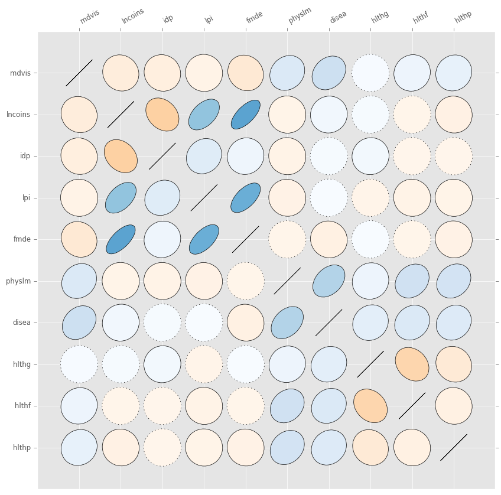

```python
import scipy

corr_matrix = np.corrcoef(randhie_df.T)

(num_rows, num_columns) = randhie_df.shape

corr_matrix = np.eye(num_columns)
p_values = np.zeros([num_rows, num_columns])

for i in range(num_columns):
    for j in range(i+1, num_columns):
        (r, p) = scipy.stats.pearsonr(randhie_df.iloc[:,i], randhie_df.iloc[:,j])
        corr_matrix[i, j] = r
        corr_matrix[j, i] = r
        p_values[i, j] = p
        p_values[j, i] = p

figure = plt.figure(figsize=(14, 10))
corrplot(corr_matrix, p_values, randhie_df.columns)
```

- Note that there is also a `plot_corr` function in statsmodels.
- However, if offers a less informative result.

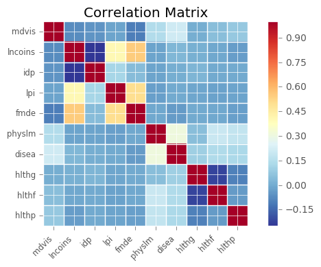

```python
import statsmodels.api as sm

fig = sm.graphics.plot_corr(corr_matrix, xnames=list(randhie_df.columns))
```

# Plotting Per Capita GDP and Life Expectancy

- The World Bank provides a wealth of data.
- Based on just a small part of this data, we can check the relationship between the per capita GDP and life expectancy in different countries.
- We download the country GDP data from http://data.worldbank.org/indicator/NY.GDP.PCAP.PP.CD.
- This is the per capita GDP at Purchasing Power Parity (PPP).

```python
import pandas as pd

gdp_df = pd.read_csv('worldbank/gdp_per_capita_ppp/API_NY.GDP.PCAP.PP.CD_DS2_en_csv_v2.csv', skiprows=4)

gdp_df[::10]
```

|  | Country Name | Country Code | Indicator Name | Indicator Code | 1960 | 1961 | 1962 | 1963 | 1964 | 1965 | ... | 2008 | 2009 | 2010 | 2011 | 2012 | 2013 | 2014 | 2015 | 2016 | Unnamed: 61 |
| --- | --- | --- | --- | --- | --- | --- | --- | --- | --- | --- | --- | --- | --- | --- | --- | --- | --- | --- | --- | --- | --- |
| 0 | Aruba | ABW | GDP per capita, PPP (current international $) | NY.GDP.PCAP.PP.CD | NaN | NaN | NaN | NaN | NaN | NaN | ... | NaN | NaN | NaN | 36015.070460 | NaN | NaN | NaN | NaN | NaN | NaN |
| 10 | Antigua and Barbuda | ATG | GDP per capita, PPP (current international $) | NY.GDP.PCAP.PP.CD | NaN | NaN | NaN | NaN | NaN | NaN | ... | 24723.111892 | 21671.375749 | 20151.309866 | 19987.924139 | 20956.336421 | 21008.146981 | 22157.581623 | 22967.692002 | NaN | NaN |
| 20 | Bahrain | BHR | GDP per capita, PPP (current international $) | NY.GDP.PCAP.PP.CD | NaN | NaN | NaN | NaN | NaN | NaN | ... | 40843.846060 | 39343.225490 | 39423.651289 | 39676.717022 | 40992.556783 | 43400.022464 | 45666.489452 | 46946.335189 | NaN | NaN |
| 30 | Bhutan | BTN | GDP per capita, PPP (current international $) | NY.GDP.PCAP.PP.CD | NaN | NaN | NaN | NaN | NaN | NaN | ... | 5418.202026 | 5717.165737 | 6354.393934 | 6882.688407 | 7251.433192 | 7418.545355 | 7844.220327 | 8076.956876 | NaN | NaN |
| 40 | Cameroon | CMR | GDP per capita, PPP (current international $) | NY.GDP.PCAP.PP.CD | NaN | NaN | NaN | NaN | NaN | NaN | ... | 2472.469533 | 2475.605671 | 2522.881810 | 2614.495561 | 2715.354110 | 2840.743075 | 2983.083040 | 3122.643965 | NaN | NaN |
| 50 | Cyprus | CYP | GDP per capita, PPP (current international $) | NY.GDP.PCAP.PP.CD | NaN | NaN | NaN | NaN | NaN | NaN | ... | 34825.577557 | 34087.759014 | 33957.901649 | 32983.185184 | 31920.445474 | 30587.424346 | 30295.212779 | 30734.175196 | NaN | NaN |
| 60 | East Asia & Pacific | EAS | GDP per capita, PPP (current international $) | NY.GDP.PCAP.PP.CD | NaN | NaN | NaN | NaN | NaN | NaN | ... | 10237.758265 | 10621.978305 | 11550.955653 | 12417.770374 | 13269.706242 | 14125.109201 | 14922.797054 | 15692.906214 | NaN | NaN |
| 70 | European Union | EUU | GDP per capita, PPP (current international $) | NY.GDP.PCAP.PP.CD | NaN | NaN | NaN | NaN | NaN | NaN | ... | 33150.630356 | 32362.787556 | 33249.376200 | 34555.748370 | 35158.863967 | 36128.661135 | 36897.739729 | 37676.470144 | NaN | NaN |
| 80 | Ghana | GHA | GDP per capita, PPP (current international $) | NY.GDP.PCAP.PP.CD | NaN | NaN | NaN | NaN | NaN | NaN | ... | 2754.883755 | 2837.014241 | 3021.484976 | 3430.857389 | 3726.643939 | 3968.056448 | 4096.584494 | 4200.547102 | NaN | NaN |
| 90 | Guam | GUM | GDP per capita, PPP (current international $) | NY.GDP.PCAP.PP.CD | NaN | NaN | NaN | NaN | NaN | NaN | ... | NaN | NaN | NaN | NaN | NaN | NaN | NaN | NaN | NaN | NaN |
| 100 | IDA & IBRD total | IBT | GDP per capita, PPP (current international $) | NY.GDP.PCAP.PP.CD | NaN | NaN | NaN | NaN | NaN | NaN | ... | 6946.795462 | 7156.393727 | 7704.847147 | 8298.593853 | 8768.997377 | 9179.886853 | 9676.143126 | 10035.315440 | NaN | NaN |
| 110 | Iraq | IRQ | GDP per capita, PPP (current international $) | NY.GDP.PCAP.PP.CD | NaN | NaN | NaN | NaN | NaN | NaN | ... | 11715.847055 | 11875.014178 | 12417.769667 | 13203.047799 | 14813.564912 | 15503.629041 | 14914.654660 | 14894.811148 | NaN | NaN |
| 120 | Cambodia | KHM | GDP per capita, PPP (current international $) | NY.GDP.PCAP.PP.CD | NaN | NaN | NaN | NaN | NaN | NaN | ... | 2346.803965 | 2331.425309 | 2462.452790 | 2648.650018 | 2846.657445 | 3058.668487 | 3274.560732 | 3483.326713 | NaN | NaN |
| 130 | Libya | LBY | GDP per capita, PPP (current international $) | NY.GDP.PCAP.PP.CD | NaN | NaN | NaN | NaN | NaN | NaN | ... | 27525.070348 | 27135.356535 | 28583.465996 | 11023.437140 | 22975.875624 | 20241.971979 | 15654.098870 | 14154.258256 | NaN | NaN |
| 140 | Late-demographic dividend | LTE | GDP per capita, PPP (current international $) | NY.GDP.PCAP.PP.CD | NaN | NaN | NaN | NaN | NaN | NaN | ... | 10168.534798 | 10563.066255 | 11490.643660 | 12618.233099 | 13506.227623 | 14241.538435 | 15114.008385 | 15745.084427 | NaN | NaN |
| 150 | Maldives | MDV | GDP per capita, PPP (current international $) | NY.GDP.PCAP.PP.CD | NaN | NaN | NaN | NaN | NaN | NaN | ... | 10227.668579 | 9791.465002 | 10301.705753 | 11126.945594 | 11373.462958 | 11855.750462 | 12575.453962 | 12636.523526 | NaN | NaN |
| 160 | Montenegro | MNE | GDP per capita, PPP (current international $) | NY.GDP.PCAP.PP.CD | NaN | NaN | NaN | NaN | NaN | NaN | ... | 13919.916982 | 13127.686836 | 13439.597682 | 14215.559181 | 13812.695943 | 14623.744841 | 15054.755006 | 15485.806092 | NaN | NaN |
| 170 | New Caledonia | NCL | GDP per capita, PPP (current international $) | NY.GDP.PCAP.PP.CD | NaN | NaN | NaN | NaN | NaN | NaN | ... | NaN | NaN | NaN | NaN | NaN | NaN | NaN | NaN | NaN | NaN |
| 180 | Oman | OMN | GDP per capita, PPP (current international $) | NY.GDP.PCAP.PP.CD | NaN | NaN | NaN | NaN | NaN | NaN | ... | 44900.790566 | 46098.887973 | 45884.958580 | 42479.201320 | 41944.999176 | 40195.517624 | 38771.838102 | 38234.053591 | NaN | NaN |
| 190 | Puerto Rico | PRI | GDP per capita, PPP (current international $) | NY.GDP.PCAP.PP.CD | NaN | NaN | NaN | NaN | NaN | NaN | ... | 34443.780369 | 34071.244891 | 33756.806862 | 34195.603665 | 34272.204418 | 35028.866735 | NaN | NaN | NaN | NaN |
| 200 | Rwanda | RWA | GDP per capita, PPP (current international $) | NY.GDP.PCAP.PP.CD | NaN | NaN | NaN | NaN | NaN | NaN | ... | 1181.544770 | 1230.524243 | 1301.696952 | 1397.224691 | 1510.678110 | 1569.395831 | 1667.332645 | 1758.733213 | NaN | NaN |
| 210 | Somalia | SOM | GDP per capita, PPP (current international $) | NY.GDP.PCAP.PP.CD | NaN | NaN | NaN | NaN | NaN | NaN | ... | NaN | NaN | NaN | NaN | NaN | NaN | NaN | NaN | NaN | NaN |
| 220 | Sweden | SWE | GDP per capita, PPP (current international $) | NY.GDP.PCAP.PP.CD | NaN | NaN | NaN | NaN | NaN | NaN | ... | 41880.840772 | 39657.241293 | 41755.980173 | 43709.211454 | 44433.726690 | 45067.437190 | 45297.765521 | 46420.418889 | NaN | NaN |
| 230 | Thailand | THA | GDP per capita, PPP (current international $) | NY.GDP.PCAP.PP.CD | NaN | NaN | NaN | NaN | NaN | NaN | ... | 12272.739798 | 12257.136177 | 13309.419197 | 13654.272460 | 14853.329683 | 15437.317229 | 15755.063465 | 16305.454564 | NaN | NaN |
| 240 | Tunisia | TUN | GDP per capita, PPP (current international $) | NY.GDP.PCAP.PP.CD | NaN | NaN | NaN | NaN | NaN | NaN | ... | 9728.978852 | 9994.097511 | 10364.571751 | 10203.801215 | 10672.567601 | 10984.913207 | 11307.800170 | 11397.235150 | NaN | NaN |
| 250 | St. Vincent and the Grenadines | VCT | GDP per capita, PPP (current international $) | NY.GDP.PCAP.PP.CD | NaN | NaN | NaN | NaN | NaN | NaN | ... | 10082.754602 | 9937.882869 | 9715.329005 | 9871.648577 | 10192.929815 | 10532.756086 | 10772.817047 | 11028.465416 | NaN | NaN |
| 260 | South Africa | ZAF | GDP per capita, PPP (current international $) | NY.GDP.PCAP.PP.CD | NaN | NaN | NaN | NaN | NaN | NaN | ... | 11792.057384 | 11529.369409 | 11847.080389 | 12291.733841 | 12598.943124 | 12881.942818 | 13083.220490 | 13165.148024 | NaN | NaN |

27 rows × 62 columns

- We'll remove the last column, which was created because the rows end in commas, therefore creating an unnamed last column.

```python
gdp_df.drop(gdp_df.columns[len(gdp_df.columns) - 1], inplace=True, axis=1)
gdp_df[::10]
```

|  | Country Name | Country Code | Indicator Name | Indicator Code | 1960 | 1961 | 1962 | 1963 | 1964 | 1965 | ... | 2007 | 2008 | 2009 | 2010 | 2011 | 2012 | 2013 | 2014 | 2015 | 2016 |
| --- | --- | --- | --- | --- | --- | --- | --- | --- | --- | --- | --- | --- | --- | --- | --- | --- | --- | --- | --- | --- | --- |
| 0 | Aruba | ABW | GDP per capita, PPP (current international $) | NY.GDP.PCAP.PP.CD | NaN | NaN | NaN | NaN | NaN | NaN | ... | NaN | NaN | NaN | NaN | 36015.070460 | NaN | NaN | NaN | NaN | NaN |
| 10 | Antigua and Barbuda | ATG | GDP per capita, PPP (current international $) | NY.GDP.PCAP.PP.CD | NaN | NaN | NaN | NaN | NaN | NaN | ... | 24503.844872 | 24723.111892 | 21671.375749 | 20151.309866 | 19987.924139 | 20956.336421 | 21008.146981 | 22157.581623 | 22967.692002 | NaN |
| 20 | Bahrain | BHR | GDP per capita, PPP (current international $) | NY.GDP.PCAP.PP.CD | NaN | NaN | NaN | NaN | NaN | NaN | ... | 40979.871576 | 40843.846060 | 39343.225490 | 39423.651289 | 39676.717022 | 40992.556783 | 43400.022464 | 45666.489452 | 46946.335189 | NaN |
| 30 | Bhutan | BTN | GDP per capita, PPP (current international $) | NY.GDP.PCAP.PP.CD | NaN | NaN | NaN | NaN | NaN | NaN | ... | 5172.726954 | 5418.202026 | 5717.165737 | 6354.393934 | 6882.688407 | 7251.433192 | 7418.545355 | 7844.220327 | 8076.956876 | NaN |
| 40 | Cameroon | CMR | GDP per capita, PPP (current international $) | NY.GDP.PCAP.PP.CD | NaN | NaN | NaN | NaN | NaN | NaN | ... | 2417.748926 | 2472.469533 | 2475.605671 | 2522.881810 | 2614.495561 | 2715.354110 | 2840.743075 | 2983.083040 | 3122.643965 | NaN |
| 50 | Cyprus | CYP | GDP per capita, PPP (current international $) | NY.GDP.PCAP.PP.CD | NaN | NaN | NaN | NaN | NaN | NaN | ... | 31767.052457 | 34825.577557 | 34087.759014 | 33957.901649 | 32983.185184 | 31920.445474 | 30587.424346 | 30295.212779 | 30734.175196 | NaN |
| 60 | East Asia & Pacific | EAS | GDP per capita, PPP (current international $) | NY.GDP.PCAP.PP.CD | NaN | NaN | NaN | NaN | NaN | NaN | ... | 9623.120158 | 10237.758265 | 10621.978305 | 11550.955653 | 12417.770374 | 13269.706242 | 14125.109201 | 14922.797054 | 15692.906214 | NaN |
| 70 | European Union | EUU | GDP per capita, PPP (current international $) | NY.GDP.PCAP.PP.CD | NaN | NaN | NaN | NaN | NaN | NaN | ... | 31836.029844 | 33150.630356 | 32362.787556 | 33249.376200 | 34555.748370 | 35158.863967 | 36128.661135 | 36897.739729 | 37676.470144 | NaN |
| 80 | Ghana | GHA | GDP per capita, PPP (current international $) | NY.GDP.PCAP.PP.CD | NaN | NaN | NaN | NaN | NaN | NaN | ... | 2539.986328 | 2754.883755 | 2837.014241 | 3021.484976 | 3430.857389 | 3726.643939 | 3968.056448 | 4096.584494 | 4200.547102 | NaN |
| 90 | Guam | GUM | GDP per capita, PPP (current international $) | NY.GDP.PCAP.PP.CD | NaN | NaN | NaN | NaN | NaN | NaN | ... | NaN | NaN | NaN | NaN | NaN | NaN | NaN | NaN | NaN | NaN |
| 100 | IDA & IBRD total | IBT | GDP per capita, PPP (current international $) | NY.GDP.PCAP.PP.CD | NaN | NaN | NaN | NaN | NaN | NaN | ... | 6456.480315 | 6946.795462 | 7156.393727 | 7704.847147 | 8298.593853 | 8768.997377 | 9179.886853 | 9676.143126 | 10035.315440 | NaN |
| 110 | Iraq | IRQ | GDP per capita, PPP (current international $) | NY.GDP.PCAP.PP.CD | NaN | NaN | NaN | NaN | NaN | NaN | ... | 10893.209802 | 11715.847055 | 11875.014178 | 12417.769667 | 13203.047799 | 14813.564912 | 15503.629041 | 14914.654660 | 14894.811148 | NaN |
| 120 | Cambodia | KHM | GDP per capita, PPP (current international $) | NY.GDP.PCAP.PP.CD | NaN | NaN | NaN | NaN | NaN | NaN | ... | 2189.504168 | 2346.803965 | 2331.425309 | 2462.452790 | 2648.650018 | 2846.657445 | 3058.668487 | 3274.560732 | 3483.326713 | NaN |
| 130 | Libya | LBY | GDP per capita, PPP (current international $) | NY.GDP.PCAP.PP.CD | NaN | NaN | NaN | NaN | NaN | NaN | ... | 26753.947408 | 27525.070348 | 27135.356535 | 28583.465996 | 11023.437140 | 22975.875624 | 20241.971979 | 15654.098870 | 14154.258256 | NaN |
| 140 | Late-demographic dividend | LTE | GDP per capita, PPP (current international $) | NY.GDP.PCAP.PP.CD | NaN | NaN | NaN | NaN | NaN | NaN | ... | 9240.337336 | 10168.534798 | 10563.066255 | 11490.643660 | 12618.233099 | 13506.227623 | 14241.538435 | 15114.008385 | 15745.084427 | NaN |
| 150 | Maldives | MDV | GDP per capita, PPP (current international $) | NY.GDP.PCAP.PP.CD | NaN | NaN | NaN | NaN | NaN | NaN | ... | 9250.395741 | 10227.668579 | 9791.465002 | 10301.705753 | 11126.945594 | 11373.462958 | 11855.750462 | 12575.453962 | 12636.523526 | NaN |
| 160 | Montenegro | MNE | GDP per capita, PPP (current international $) | NY.GDP.PCAP.PP.CD | NaN | NaN | NaN | NaN | NaN | NaN | ... | 12483.186260 | 13919.916982 | 13127.686836 | 13439.597682 | 14215.559181 | 13812.695943 | 14623.744841 | 15054.755006 | 15485.806092 | NaN |
| 170 | New Caledonia | NCL | GDP per capita, PPP (current international $) | NY.GDP.PCAP.PP.CD | NaN | NaN | NaN | NaN | NaN | NaN | ... | NaN | NaN | NaN | NaN | NaN | NaN | NaN | NaN | NaN | NaN |
| 180 | Oman | OMN | GDP per capita, PPP (current international $) | NY.GDP.PCAP.PP.CD | NaN | NaN | NaN | NaN | NaN | NaN | ... | 41618.140626 | 44900.790566 | 46098.887973 | 45884.958580 | 42479.201320 | 41944.999176 | 40195.517624 | 38771.838102 | 38234.053591 | NaN |
| 190 | Puerto Rico | PRI | GDP per capita, PPP (current international $) | NY.GDP.PCAP.PP.CD | NaN | NaN | NaN | NaN | NaN | NaN | ... | 34198.688483 | 34443.780369 | 34071.244891 | 33756.806862 | 34195.603665 | 34272.204418 | 35028.866735 | NaN | NaN | NaN |
| 200 | Rwanda | RWA | GDP per capita, PPP (current international $) | NY.GDP.PCAP.PP.CD | NaN | NaN | NaN | NaN | NaN | NaN | ... | 1072.052347 | 1181.544770 | 1230.524243 | 1301.696952 | 1397.224691 | 1510.678110 | 1569.395831 | 1667.332645 | 1758.733213 | NaN |
| 210 | Somalia | SOM | GDP per capita, PPP (current international $) | NY.GDP.PCAP.PP.CD | NaN | NaN | NaN | NaN | NaN | NaN | ... | NaN | NaN | NaN | NaN | NaN | NaN | NaN | NaN | NaN | NaN |
| 220 | Sweden | SWE | GDP per capita, PPP (current international $) | NY.GDP.PCAP.PP.CD | NaN | NaN | NaN | NaN | NaN | NaN | ... | 40560.894301 | 41880.840772 | 39657.241293 | 41755.980173 | 43709.211454 | 44433.726690 | 45067.437190 | 45297.765521 | 46420.418889 | NaN |
| 230 | Thailand | THA | GDP per capita, PPP (current international $) | NY.GDP.PCAP.PP.CD | NaN | NaN | NaN | NaN | NaN | NaN | ... | 11850.215089 | 12272.739798 | 12257.136177 | 13309.419197 | 13654.272460 | 14853.329683 | 15437.317229 | 15755.063465 | 16305.454564 | NaN |
| 240 | Tunisia | TUN | GDP per capita, PPP (current international $) | NY.GDP.PCAP.PP.CD | NaN | NaN | NaN | NaN | NaN | NaN | ... | 9246.809984 | 9728.978852 | 9994.097511 | 10364.571751 | 10203.801215 | 10672.567601 | 10984.913207 | 11307.800170 | 11397.235150 | NaN |
| 250 | St. Vincent and the Grenadines | VCT | GDP per capita, PPP (current international $) | NY.GDP.PCAP.PP.CD | NaN | NaN | NaN | NaN | NaN | NaN | ... | 9274.910242 | 10082.754602 | 9937.882869 | 9715.329005 | 9871.648577 | 10192.929815 | 10532.756086 | 10772.817047 | 11028.465416 | NaN |
| 260 | South Africa | ZAF | GDP per capita, PPP (current international $) | NY.GDP.PCAP.PP.CD | NaN | NaN | NaN | NaN | NaN | NaN | ... | 11368.862713 | 11792.057384 | 11529.369409 | 11847.080389 | 12291.733841 | 12598.943124 | 12881.942818 | 13083.220490 | 13165.148024 | NaN |

27 rows × 61 columns

- We see that some rows do not deal with countries, but with aggregates.
- We can find out which rows we should discard by turning to the countries metadata (included as a separate file in the dataset we downloaded previously).
- Note that this file starts with a Byte Order Mark (as did the previous one, in fact, but we did not notice because we skipped the first rows). So we need to adjust our encoding to `utf-8-sig`.

```python
countries_df = pd.read_csv('worldbank/gdp_per_capita_ppp/Metadata_Country_API_NY.GDP.PCAP.PP.CD_DS2_en_csv_v2.csv',
                           encoding="utf-8-sig")
print(countries_df.shape)
countries_df
```

```
(263, 6)
```

|  | "Country Code" | Region | IncomeGroup | SpecialNotes | TableName | Unnamed: 5 |
| --- | --- | --- | --- | --- | --- | --- |
| 0 | ABW | Latin America & Caribbean | High income | SNA data for 2000-2011 are updated from offici... | Aruba | NaN |
| 1 | AFG | South Asia | Low income | Fiscal year end: March 20; reporting period fo... | Afghanistan | NaN |
| 2 | AGO | Sub-Saharan Africa | Upper middle income | April 2013 database update: Based on IMF data,... | Angola | NaN |
| 3 | ALB | Europe & Central Asia | Upper middle income | NaN | Albania | NaN |
| 4 | AND | Europe & Central Asia | High income | The base year has changed to 2000. Price valua... | Andorra | NaN |
| 5 | ARB | NaN | NaN | Arab World aggregate. Arab World is composed o... | Arab World | NaN |
| 6 | ARE | Middle East & North Africa | High income | April 2013 database update: Based on data from... | United Arab Emirates | NaN |
| 7 | ARG | Latin America & Caribbean | Upper middle income | Argentina, which was temporarily unclassified ... | Argentina | NaN |
| 8 | ARM | Europe & Central Asia | Lower middle income | NaN | Armenia | NaN |
| 9 | ASM | East Asia & Pacific | Upper middle income | NaN | American Samoa | NaN |
| 10 | ATG | Latin America & Caribbean | High income | April 2012 database update: Based on official ... | Antigua and Barbuda | NaN |
| 11 | AUS | East Asia & Pacific | High income | Fiscal year end: June 30; reporting period for... | Australia | NaN |
| 12 | AUT | Europe & Central Asia | High income | A simple multiplier is used to convert the nat... | Austria | NaN |
| 13 | AZE | Europe & Central Asia | Upper middle income | April 2012 database update: National accounts ... | Azerbaijan | NaN |
| 14 | BDI | Sub-Saharan Africa | Low income | NaN | Burundi | NaN |
| 15 | BEL | Europe & Central Asia | High income | A simple multiplier is used to convert the nat... | Belgium | NaN |
| 16 | BEN | Sub-Saharan Africa | Low income | Based on official government statistics, the n... | Benin | NaN |
| 17 | BFA | Sub-Saharan Africa | Low income | NaN | Burkina Faso | NaN |
| 18 | BGD | South Asia | Lower middle income | Fiscal year end: June 30; reporting period for... | Bangladesh | NaN |
| 19 | BGR | Europe & Central Asia | Upper middle income | The new reference year for chain linked series... | Bulgaria | NaN |
| 20 | BHR | Middle East & North Africa | High income | Based on official government statistics; the n... | Bahrain | NaN |
| 21 | BHS | Latin America & Caribbean | High income | NaN | Bahamas, The | NaN |
| 22 | BIH | Europe & Central Asia | Upper middle income | Based on official government statistics for ch... | Bosnia and Herzegovina | NaN |
| 23 | BLR | Europe & Central Asia | Upper middle income | In July 2016 a new Belarusian ruble was introd... | Belarus | NaN |
| 24 | BLZ | Latin America & Caribbean | Upper middle income | NaN | Belize | NaN |
| 25 | BMU | North America | High income | NaN | Bermuda | NaN |
| 26 | BOL | Latin America & Caribbean | Lower middle income | NaN | Bolivia | NaN |
| 27 | BRA | Latin America & Caribbean | Upper middle income | Based on official government statistics, the n... | Brazil | NaN |
| 28 | BRB | Latin America & Caribbean | High income | NaN | Barbados | NaN |
| 29 | BRN | East Asia & Pacific | High income | NaN | Brunei Darussalam | NaN |
| ... | ... | ... | ... | ... | ... | ... |
| 233 | TKM | Europe & Central Asia | Upper middle income | On January 1, 2009, the Turkmen manat was rede... | Turkmenistan | NaN |
| 234 | TLA | NaN | NaN | Latin America & the Caribbean (IDA & IBRD coun... | Latin America & Caribbean (IDA & IBRD) | NaN |
| 235 | TLS | East Asia & Pacific | Lower middle income | Based on official government statistics, natio... | Timor-Leste | NaN |
| 236 | TMN | NaN | NaN | Middle East & North Africa (IDA & IBRD countri... | Middle East & North Africa (IDA & IBRD) | NaN |
| 237 | TON | East Asia & Pacific | Lower middle income | 2013 national accounts estimates are based on ... | Tonga | NaN |
| 238 | TSA | NaN | NaN | South Asia (IDA & IBRD countries) aggregate. | South Asia (IDA & IBRD) | NaN |
| 239 | TSS | NaN | NaN | Sub-Saharan Africa (IDA & IBRD countries) aggr... | Sub-Saharan Africa (IDA & IBRD) | NaN |
| 240 | TTO | Latin America & Caribbean | High income | NaN | Trinidad and Tobago | NaN |
| 241 | TUN | Middle East & North Africa | Lower middle income | Based on data from Tunisia’s Ministry of Devel... | Tunisia | NaN |
| 242 | TUR | Europe & Central Asia | Upper middle income | NaN | Turkey | NaN |
| 243 | TUV | East Asia & Pacific | Upper middle income | 2013 national accounts estimates are based on ... | Tuvalu | NaN |
| 244 | TZA | Sub-Saharan Africa | Low income | The new base year is 2007. Tanzania reports us... | Tanzania | NaN |
| 245 | UGA | Sub-Saharan Africa | Low income | Fiscal year end: June 30; reporting period for... | Uganda | NaN |
| 246 | UKR | Europe & Central Asia | Lower middle income | NaN | Ukraine | NaN |
| 247 | UMC | NaN | NaN | Upper middle income group aggregate. Upper-mid... | Upper middle income | NaN |
| 248 | URY | Latin America & Caribbean | High income | In 2011, the Central Bank revised national acc... | Uruguay | NaN |
| 249 | USA | North America | High income | Fiscal year end: September 30; reporting perio... | United States | NaN |
| 250 | UZB | Europe & Central Asia | Lower middle income | NaN | Uzbekistan | NaN |
| 251 | VCT | Latin America & Caribbean | Upper middle income | April 2012 database update: Based on official ... | St. Vincent and the Grenadines | NaN |
| 252 | VEN | Latin America & Caribbean | Upper middle income | NaN | Venezuela, RB | NaN |
| 253 | VGB | Latin America & Caribbean | High income | NaN | British Virgin Islands | NaN |
| 254 | VIR | Latin America & Caribbean | High income | NaN | Virgin Islands (U.S.) | NaN |
| 255 | VNM | East Asia & Pacific | Lower middle income | National accounts value added data are now rep... | Vietnam | NaN |
| 256 | VUT | East Asia & Pacific | Lower middle income | 2013 national accounts estimates are based on ... | Vanuatu | NaN |
| 257 | WLD | NaN | NaN | World aggregate. | World | NaN |
| 258 | WSM | East Asia & Pacific | Lower middle income | Fiscal year ends on June 30; reporting period ... | Samoa | NaN |
| 259 | YEM | Middle East & North Africa | Lower middle income | Based on official government statistics and In... | Yemen, Rep. | NaN |
| 260 | ZAF | Sub-Saharan Africa | Upper middle income | Fiscal year end: March 31; reporting period fo... | South Africa | NaN |
| 261 | ZMB | Sub-Saharan Africa | Lower middle income | The new base year is 2010. National accounts d... | Zambia | NaN |
| 262 | ZWE | Sub-Saharan Africa | Low income | Fiscal year end: June 30; reporting period for... | Zimbabwe | NaN |

263 rows × 6 columns

- We see that the first column is in quotes; that is because of the BOM, so we'll rename it.
- Also, we'll remove the last column.
- To get only the actual countries we'll remove those rows without an entry for the Region column.

```python
countries_df = countries_df.rename(columns = {'"Country Code"': 'Country Code'})
countries_df.drop(countries_df.columns[len(countries_df.columns) - 1], inplace=True, axis=1)
countries_df = countries_df[countries_df['Region'].notnull()]
print(countries_df.shape)
countries_df
```

```
(217, 5)
```

|  | Country Code | Region | IncomeGroup | SpecialNotes | TableName |
| --- | --- | --- | --- | --- | --- |
| 0 | ABW | Latin America & Caribbean | High income | SNA data for 2000-2011 are updated from offici... | Aruba |
| 1 | AFG | South Asia | Low income | Fiscal year end: March 20; reporting period fo... | Afghanistan |
| 2 | AGO | Sub-Saharan Africa | Upper middle income | April 2013 database update: Based on IMF data,... | Angola |
| 3 | ALB | Europe & Central Asia | Upper middle income | NaN | Albania |
| 4 | AND | Europe & Central Asia | High income | The base year has changed to 2000. Price valua... | Andorra |
| 6 | ARE | Middle East & North Africa | High income | April 2013 database update: Based on data from... | United Arab Emirates |
| 7 | ARG | Latin America & Caribbean | Upper middle income | Argentina, which was temporarily unclassified ... | Argentina |
| 8 | ARM | Europe & Central Asia | Lower middle income | NaN | Armenia |
| 9 | ASM | East Asia & Pacific | Upper middle income | NaN | American Samoa |
| 10 | ATG | Latin America & Caribbean | High income | April 2012 database update: Based on official ... | Antigua and Barbuda |
| 11 | AUS | East Asia & Pacific | High income | Fiscal year end: June 30; reporting period for... | Australia |
| 12 | AUT | Europe & Central Asia | High income | A simple multiplier is used to convert the nat... | Austria |
| 13 | AZE | Europe & Central Asia | Upper middle income | April 2012 database update: National accounts ... | Azerbaijan |
| 14 | BDI | Sub-Saharan Africa | Low income | NaN | Burundi |
| 15 | BEL | Europe & Central Asia | High income | A simple multiplier is used to convert the nat... | Belgium |
| 16 | BEN | Sub-Saharan Africa | Low income | Based on official government statistics, the n... | Benin |
| 17 | BFA | Sub-Saharan Africa | Low income | NaN | Burkina Faso |
| 18 | BGD | South Asia | Lower middle income | Fiscal year end: June 30; reporting period for... | Bangladesh |
| 19 | BGR | Europe & Central Asia | Upper middle income | The new reference year for chain linked series... | Bulgaria |
| 20 | BHR | Middle East & North Africa | High income | Based on official government statistics; the n... | Bahrain |
| 21 | BHS | Latin America & Caribbean | High income | NaN | Bahamas, The |
| 22 | BIH | Europe & Central Asia | Upper middle income | Based on official government statistics for ch... | Bosnia and Herzegovina |
| 23 | BLR | Europe & Central Asia | Upper middle income | In July 2016 a new Belarusian ruble was introd... | Belarus |
| 24 | BLZ | Latin America & Caribbean | Upper middle income | NaN | Belize |
| 25 | BMU | North America | High income | NaN | Bermuda |
| 26 | BOL | Latin America & Caribbean | Lower middle income | NaN | Bolivia |
| 27 | BRA | Latin America & Caribbean | Upper middle income | Based on official government statistics, the n... | Brazil |
| 28 | BRB | Latin America & Caribbean | High income | NaN | Barbados |
| 29 | BRN | East Asia & Pacific | High income | NaN | Brunei Darussalam |
| 30 | BTN | South Asia | Lower middle income | April 2013 database update: Data were updated ... | Bhutan |
| ... | ... | ... | ... | ... | ... |
| 225 | SYR | Middle East & North Africa | Lower middle income | April 2013 database update: Based on data from... | Syrian Arab Republic |
| 226 | TCA | Latin America & Caribbean | High income | NaN | Turks and Caicos Islands |
| 227 | TCD | Sub-Saharan Africa | Low income | Based on IMF data, national accounts data have... | Chad |
| 230 | TGO | Sub-Saharan Africa | Low income | April 2013 database update: Based on IMF data,... | Togo |
| 231 | THA | East Asia & Pacific | Upper middle income | Fiscal year end: September 30; reporting perio... | Thailand |
| 232 | TJK | Europe & Central Asia | Lower middle income | NaN | Tajikistan |
| 233 | TKM | Europe & Central Asia | Upper middle income | On January 1, 2009, the Turkmen manat was rede... | Turkmenistan |
| 235 | TLS | East Asia & Pacific | Lower middle income | Based on official government statistics, natio... | Timor-Leste |
| 237 | TON | East Asia & Pacific | Lower middle income | 2013 national accounts estimates are based on ... | Tonga |
| 240 | TTO | Latin America & Caribbean | High income | NaN | Trinidad and Tobago |
| 241 | TUN | Middle East & North Africa | Lower middle income | Based on data from Tunisia’s Ministry of Devel... | Tunisia |
| 242 | TUR | Europe & Central Asia | Upper middle income | NaN | Turkey |
| 243 | TUV | East Asia & Pacific | Upper middle income | 2013 national accounts estimates are based on ... | Tuvalu |
| 244 | TZA | Sub-Saharan Africa | Low income | The new base year is 2007. Tanzania reports us... | Tanzania |
| 245 | UGA | Sub-Saharan Africa | Low income | Fiscal year end: June 30; reporting period for... | Uganda |
| 246 | UKR | Europe & Central Asia | Lower middle income | NaN | Ukraine |
| 248 | URY | Latin America & Caribbean | High income | In 2011, the Central Bank revised national acc... | Uruguay |
| 249 | USA | North America | High income | Fiscal year end: September 30; reporting perio... | United States |
| 250 | UZB | Europe & Central Asia | Lower middle income | NaN | Uzbekistan |
| 251 | VCT | Latin America & Caribbean | Upper middle income | April 2012 database update: Based on official ... | St. Vincent and the Grenadines |
| 252 | VEN | Latin America & Caribbean | Upper middle income | NaN | Venezuela, RB |
| 253 | VGB | Latin America & Caribbean | High income | NaN | British Virgin Islands |
| 254 | VIR | Latin America & Caribbean | High income | NaN | Virgin Islands (U.S.) |
| 255 | VNM | East Asia & Pacific | Lower middle income | National accounts value added data are now rep... | Vietnam |
| 256 | VUT | East Asia & Pacific | Lower middle income | 2013 national accounts estimates are based on ... | Vanuatu |
| 258 | WSM | East Asia & Pacific | Lower middle income | Fiscal year ends on June 30; reporting period ... | Samoa |
| 259 | YEM | Middle East & North Africa | Lower middle income | Based on official government statistics and In... | Yemen, Rep. |
| 260 | ZAF | Sub-Saharan Africa | Upper middle income | Fiscal year end: March 31; reporting period fo... | South Africa |
| 261 | ZMB | Sub-Saharan Africa | Lower middle income | The new base year is 2010. National accounts d... | Zambia |
| 262 | ZWE | Sub-Saharan Africa | Low income | Fiscal year end: June 30; reporting period for... | Zimbabwe |

217 rows × 5 columns

- Now we can merge the countries with the GDP data, so that we'll have the actual countries with their GDP and their geographical region.

```python
gdp_countries_df = pd.merge(gdp_df,
                            countries_df[["Country Code", "Region"]],
                            how="inner",
                            on="Country Code")
print(gdp_countries_df.shape)
gdp_countries_df
```

```
(217, 62)
```

|  | Country Name | Country Code | Indicator Name | Indicator Code | 1960 | 1961 | 1962 | 1963 | 1964 | 1965 | ... | 2008 | 2009 | 2010 | 2011 | 2012 | 2013 | 2014 | 2015 | 2016 | Region |
| --- | --- | --- | --- | --- | --- | --- | --- | --- | --- | --- | --- | --- | --- | --- | --- | --- | --- | --- | --- | --- | --- |
| 0 | Aruba | ABW | GDP per capita, PPP (current international $) | NY.GDP.PCAP.PP.CD | NaN | NaN | NaN | NaN | NaN | NaN | ... | NaN | NaN | NaN | 36015.070460 | NaN | NaN | NaN | NaN | NaN | Latin America & Caribbean |
| 1 | Andorra | AND | GDP per capita, PPP (current international $) | NY.GDP.PCAP.PP.CD | NaN | NaN | NaN | NaN | NaN | NaN | ... | NaN | NaN | NaN | NaN | NaN | NaN | NaN | NaN | NaN | Europe & Central Asia |
| 2 | Afghanistan | AFG | GDP per capita, PPP (current international $) | NY.GDP.PCAP.PP.CD | NaN | NaN | NaN | NaN | NaN | NaN | ... | 1283.040986 | 1525.517054 | 1629.167290 | 1712.588720 | 1934.285634 | 1941.898323 | 1939.954125 | 1934.193634 | NaN | South Asia |
| 3 | Angola | AGO | GDP per capita, PPP (current international $) | NY.GDP.PCAP.PP.CD | NaN | NaN | NaN | NaN | NaN | NaN | ... | 6298.012440 | 6284.274905 | 6360.848980 | 6524.481181 | 6758.278050 | 7097.840138 | 7317.834073 | 7371.027656 | NaN | Sub-Saharan Africa |
| 4 | Albania | ALB | GDP per capita, PPP (current international $) | NY.GDP.PCAP.PP.CD | NaN | NaN | NaN | NaN | NaN | NaN | ... | 8769.094336 | 9342.081246 | 9303.932476 | 9640.144593 | 10361.433216 | 10412.441721 | 11167.022573 | 11305.417422 | NaN | Europe & Central Asia |
| 5 | United Arab Emirates | ARE | GDP per capita, PPP (current international $) | NY.GDP.PCAP.PP.CD | NaN | NaN | NaN | NaN | NaN | NaN | ... | 69124.396211 | 59100.380538 | 56245.478159 | 57594.126683 | 61172.994788 | 64229.464986 | 67921.399464 | 70237.947749 | NaN | Middle East & North Africa |
| 6 | Argentina | ARG | GDP per capita, PPP (current international $) | NY.GDP.PCAP.PP.CD | NaN | NaN | NaN | NaN | NaN | NaN | ... | NaN | NaN | NaN | NaN | NaN | NaN | NaN | NaN | NaN | Latin America & Caribbean |
| 7 | Armenia | ARM | GDP per capita, PPP (current international $) | NY.GDP.PCAP.PP.CD | NaN | NaN | NaN | NaN | NaN | NaN | ... | 7097.912173 | 6158.301452 | 6376.268217 | 6803.482997 | 7401.856398 | 7734.780167 | 8099.208326 | 8393.511786 | NaN | Europe & Central Asia |
| 8 | American Samoa | ASM | GDP per capita, PPP (current international $) | NY.GDP.PCAP.PP.CD | NaN | NaN | NaN | NaN | NaN | NaN | ... | NaN | NaN | NaN | NaN | NaN | NaN | NaN | NaN | NaN | East Asia & Pacific |
| 9 | Antigua and Barbuda | ATG | GDP per capita, PPP (current international $) | NY.GDP.PCAP.PP.CD | NaN | NaN | NaN | NaN | NaN | NaN | ... | 24723.111892 | 21671.375749 | 20151.309866 | 19987.924139 | 20956.336421 | 21008.146981 | 22157.581623 | 22967.692002 | NaN | Latin America & Caribbean |
| 10 | Australia | AUS | GDP per capita, PPP (current international $) | NY.GDP.PCAP.PP.CD | NaN | NaN | NaN | NaN | NaN | NaN | ... | 37479.289120 | 40257.168617 | 39168.256720 | 41763.118512 | 42596.294119 | 45476.976588 | 45937.300039 | 45514.175830 | NaN | East Asia & Pacific |
| 11 | Austria | AUT | GDP per capita, PPP (current international $) | NY.GDP.PCAP.PP.CD | NaN | NaN | NaN | NaN | NaN | NaN | ... | 41151.585043 | 40620.392157 | 41892.775849 | 44022.395275 | 45858.246836 | 47416.284670 | 47706.488247 | 47824.187778 | NaN | Europe & Central Asia |
| 12 | Azerbaijan | AZE | GDP per capita, PPP (current international $) | NY.GDP.PCAP.PP.CD | NaN | NaN | NaN | NaN | NaN | NaN | ... | 13799.786140 | 14900.508664 | 15627.605620 | 15754.152363 | 16180.887150 | 17174.310881 | 17584.685348 | 17739.954736 | NaN | Europe & Central Asia |
| 13 | Burundi | BDI | GDP per capita, PPP (current international $) | NY.GDP.PCAP.PP.CD | NaN | NaN | NaN | NaN | NaN | NaN | ... | 679.061456 | 683.468685 | 693.470003 | 712.670483 | 730.033566 | 750.705845 | 772.695122 | 736.011834 | NaN | Sub-Saharan Africa |
| 14 | Belgium | BEL | GDP per capita, PPP (current international $) | NY.GDP.PCAP.PP.CD | NaN | NaN | NaN | NaN | NaN | NaN | ... | 37846.955591 | 37629.442842 | 39257.834474 | 40858.725170 | 41930.661833 | 43057.203592 | 43409.240892 | 43991.622895 | NaN | Europe & Central Asia |
| 15 | Benin | BEN | GDP per capita, PPP (current international $) | NY.GDP.PCAP.PP.CD | NaN | NaN | NaN | NaN | NaN | NaN | ... | 1714.280209 | 1716.207268 | 1723.796926 | 1761.574331 | 1826.808935 | 1931.929514 | 2037.586205 | 2109.845957 | NaN | Sub-Saharan Africa |
| 16 | Burkina Faso | BFA | GDP per capita, PPP (current international $) | NY.GDP.PCAP.PP.CD | NaN | NaN | NaN | NaN | NaN | NaN | ... | 1300.498069 | 1308.546046 | 1393.562721 | 1470.435184 | 1547.649372 | 1583.161865 | 1626.266913 | 1659.220243 | NaN | Sub-Saharan Africa |
| 17 | Bangladesh | BGD | GDP per capita, PPP (current international $) | NY.GDP.PCAP.PP.CD | NaN | NaN | NaN | NaN | NaN | NaN | ... | 2171.629728 | 2273.164201 | 2401.718740 | 2579.335048 | 2764.781928 | 2942.810045 | 3134.154252 | 3332.803445 | NaN | South Asia |
| 18 | Bulgaria | BGR | GDP per capita, PPP (current international $) | NY.GDP.PCAP.PP.CD | NaN | NaN | NaN | NaN | NaN | NaN | ... | 14934.774464 | 14870.805406 | 15084.322160 | 15603.051663 | 16097.834314 | 16573.470340 | 17207.595335 | 17511.764115 | NaN | Europe & Central Asia |
| 19 | Bahrain | BHR | GDP per capita, PPP (current international $) | NY.GDP.PCAP.PP.CD | NaN | NaN | NaN | NaN | NaN | NaN | ... | 40843.846060 | 39343.225490 | 39423.651289 | 39676.717022 | 40992.556783 | 43400.022464 | 45666.489452 | 46946.335189 | NaN | Middle East & North Africa |
| 20 | Bahamas, The | BHS | GDP per capita, PPP (current international $) | NY.GDP.PCAP.PP.CD | NaN | NaN | NaN | NaN | NaN | NaN | ... | 23397.815772 | 22196.819494 | 22431.137635 | 22665.167557 | 23234.792225 | 23277.877670 | 23576.960515 | 23795.438295 | NaN | Latin America & Caribbean |
| 21 | Bosnia and Herzegovina | BIH | GDP per capita, PPP (current international $) | NY.GDP.PCAP.PP.CD | NaN | NaN | NaN | NaN | NaN | NaN | ... | 8796.280753 | 8686.598414 | 8941.522708 | 9422.276108 | 9705.013979 | 10115.540404 | 10426.917278 | 10509.651420 | NaN | Europe & Central Asia |
| 22 | Belarus | BLR | GDP per capita, PPP (current international $) | NY.GDP.PCAP.PP.CD | NaN | NaN | NaN | NaN | NaN | NaN | ... | 13917.756755 | 14082.538284 | 15385.459273 | 16603.389530 | 17218.356100 | 17683.164302 | 18250.563217 | 17660.946586 | NaN | Europe & Central Asia |
| 23 | Belize | BLZ | GDP per capita, PPP (current international $) | NY.GDP.PCAP.PP.CD | NaN | NaN | NaN | NaN | NaN | NaN | ... | 7630.700312 | 7558.521501 | 7716.057237 | 7855.674423 | 8114.443709 | 8173.297557 | 8461.957885 | 8526.927511 | NaN | Latin America & Caribbean |
| 24 | Bermuda | BMU | GDP per capita, PPP (current international $) | NY.GDP.PCAP.PP.CD | NaN | NaN | NaN | NaN | NaN | NaN | ... | 58288.612094 | 55320.161711 | 55254.214119 | 54984.510395 | 53097.696288 | 52443.841661 | NaN | NaN | NaN | North America |
| 25 | Bolivia | BOL | GDP per capita, PPP (current international $) | NY.GDP.PCAP.PP.CD | NaN | NaN | NaN | NaN | NaN | NaN | ... | 4986.848846 | 5108.846894 | 5298.082910 | 5598.566773 | 5899.781303 | 6304.204096 | 6654.038846 | 6880.903359 | NaN | Latin America & Caribbean |
| 26 | Brazil | BRA | GDP per capita, PPP (current international $) | NY.GDP.PCAP.PP.CD | NaN | NaN | NaN | NaN | NaN | NaN | ... | 13140.762264 | 13093.997222 | 14114.518544 | 14827.146718 | 15246.260766 | 15816.800400 | 15951.221219 | 15359.326297 | NaN | Latin America & Caribbean |
| 27 | Barbados | BRB | GDP per capita, PPP (current international $) | NY.GDP.PCAP.PP.CD | NaN | NaN | NaN | NaN | NaN | NaN | ... | 15444.691525 | 14872.864480 | 15036.362530 | 15401.549650 | 15673.173313 | 15876.618302 | 16116.487565 | 16390.864923 | NaN | Latin America & Caribbean |
| 28 | Brunei Darussalam | BRN | GDP per capita, PPP (current international $) | NY.GDP.PCAP.PP.CD | NaN | NaN | NaN | NaN | NaN | NaN | ... | 70824.084445 | 68962.855214 | 70486.333061 | 73265.121635 | 74195.021192 | 73005.555456 | 71444.898781 | 70817.018510 | NaN | East Asia & Pacific |
| 29 | Bhutan | BTN | GDP per capita, PPP (current international $) | NY.GDP.PCAP.PP.CD | NaN | NaN | NaN | NaN | NaN | NaN | ... | 5418.202026 | 5717.165737 | 6354.393934 | 6882.688407 | 7251.433192 | 7418.545355 | 7844.220327 | 8076.956876 | NaN | South Asia |
| ... | ... | ... | ... | ... | ... | ... | ... | ... | ... | ... | ... | ... | ... | ... | ... | ... | ... | ... | ... | ... | ... |
| 187 | Chad | TCD | GDP per capita, PPP (current international $) | NY.GDP.PCAP.PP.CD | NaN | NaN | NaN | NaN | NaN | NaN | ... | 1667.697393 | 1694.821571 | 1884.795827 | 1862.351166 | 1997.410939 | 2075.440880 | 2181.852455 | 2171.400812 | NaN | Sub-Saharan Africa |
| 188 | Togo | TGO | GDP per capita, PPP (current international $) | NY.GDP.PCAP.PP.CD | NaN | NaN | NaN | NaN | NaN | NaN | ... | 1158.458470 | 1175.823679 | 1204.604894 | 1255.087825 | 1304.187972 | 1341.614534 | 1406.764974 | 1459.796727 | NaN | Sub-Saharan Africa |
| 189 | Thailand | THA | GDP per capita, PPP (current international $) | NY.GDP.PCAP.PP.CD | NaN | NaN | NaN | NaN | NaN | NaN | ... | 12272.739798 | 12257.136177 | 13309.419197 | 13654.272460 | 14853.329683 | 15437.317229 | 15755.063465 | 16305.454564 | NaN | East Asia & Pacific |
| 190 | Tajikistan | TJK | GDP per capita, PPP (current international $) | NY.GDP.PCAP.PP.CD | NaN | NaN | NaN | NaN | NaN | NaN | ... | 1928.200965 | 1972.915229 | 2080.044388 | 2229.445742 | 2386.327474 | 2546.586587 | 2700.584241 | 2779.876143 | NaN | Europe & Central Asia |
| 191 | Turkmenistan | TKM | GDP per capita, PPP (current international $) | NY.GDP.PCAP.PP.CD | NaN | NaN | NaN | NaN | NaN | NaN | ... | 8528.113320 | 9004.579189 | 9828.662204 | 11360.502149 | 12689.343828 | 14029.494786 | 15529.864455 | 16498.892954 | NaN | Europe & Central Asia |
| 192 | Timor-Leste | TLS | GDP per capita, PPP (current international $) | NY.GDP.PCAP.PP.CD | NaN | NaN | NaN | NaN | NaN | NaN | ... | 1516.904332 | 1697.342272 | 1847.226269 | 1965.522007 | 2075.984742 | 2110.844029 | 2203.692832 | 2259.061940 | NaN | East Asia & Pacific |
| 193 | Tonga | TON | GDP per capita, PPP (current international $) | NY.GDP.PCAP.PP.CD | NaN | NaN | NaN | NaN | NaN | NaN | ... | 4567.116508 | 4625.408634 | 4852.021362 | 5030.652213 | 5132.805233 | 5059.039416 | 5230.151294 | NaN | NaN | East Asia & Pacific |
| 194 | Trinidad and Tobago | TTO | GDP per capita, PPP (current international $) | NY.GDP.PCAP.PP.CD | NaN | NaN | NaN | NaN | NaN | NaN | ... | 30374.548547 | 29123.050116 | 29307.871160 | 29765.011935 | 30571.906353 | 31454.631583 | 32083.799608 | 32596.514889 | NaN | Latin America & Caribbean |
| 195 | Tunisia | TUN | GDP per capita, PPP (current international $) | NY.GDP.PCAP.PP.CD | NaN | NaN | NaN | NaN | NaN | NaN | ... | 9728.978852 | 9994.097511 | 10364.571751 | 10203.801215 | 10672.567601 | 10984.913207 | 11307.800170 | 11397.235150 | NaN | Middle East & North Africa |
| 196 | Turkey | TUR | GDP per capita, PPP (current international $) | NY.GDP.PCAP.PP.CD | NaN | NaN | NaN | NaN | NaN | NaN | ... | 15181.658637 | 14651.100409 | 16165.812368 | 17796.475188 | 18449.250016 | 19042.880416 | 19390.381137 | 19618.224711 | NaN | Europe & Central Asia |
| 197 | Tuvalu | TUV | GDP per capita, PPP (current international $) | NY.GDP.PCAP.PP.CD | NaN | NaN | NaN | NaN | NaN | NaN | ... | 3342.866072 | 3212.379397 | 3156.748086 | 3488.248359 | 3552.926553 | 3651.792278 | 3779.059730 | NaN | NaN | East Asia & Pacific |
| 198 | Tanzania | TZA | GDP per capita, PPP (current international $) | NY.GDP.PCAP.PP.CD | NaN | NaN | NaN | NaN | NaN | NaN | ... | 1927.688998 | 1983.222862 | 2068.488487 | 2206.910779 | 2289.261876 | 2417.772730 | 2547.167957 | 2667.290661 | NaN | Sub-Saharan Africa |
| 199 | Uganda | UGA | GDP per capita, PPP (current international $) | NY.GDP.PCAP.PP.CD | NaN | NaN | NaN | NaN | NaN | NaN | ... | 1414.153425 | 1478.044546 | 1522.078551 | 1648.531066 | 1696.494424 | 1723.446179 | 1777.327190 | 1825.307071 | NaN | Sub-Saharan Africa |
| 200 | Ukraine | UKR | GDP per capita, PPP (current international $) | NY.GDP.PCAP.PP.CD | NaN | NaN | NaN | NaN | NaN | NaN | ... | 8417.004142 | 7257.897526 | 7685.569632 | 8281.867126 | 8472.201129 | 8629.934387 | 8666.902913 | 7915.870874 | NaN | Europe & Central Asia |
| 201 | Uruguay | URY | GDP per capita, PPP (current international $) | NY.GDP.PCAP.PP.CD | NaN | NaN | NaN | NaN | NaN | NaN | ... | 14705.516636 | 15391.169532 | 16736.855995 | 17904.819864 | 18817.874922 | 19945.675638 | 20859.249139 | 21200.587811 | NaN | Latin America & Caribbean |
| 202 | United States | USA | GDP per capita, PPP (current international $) | NY.GDP.PCAP.PP.CD | NaN | NaN | NaN | NaN | NaN | NaN | ... | 48401.427340 | 47001.555350 | 48374.086793 | 49781.800656 | 51433.047090 | 52660.295105 | 54398.460009 | 55836.792631 | NaN | North America |
| 203 | Uzbekistan | UZB | GDP per capita, PPP (current international $) | NY.GDP.PCAP.PP.CD | NaN | NaN | NaN | NaN | NaN | NaN | ... | 3585.991287 | 3840.542875 | 4100.482835 | 4412.474193 | 4791.189289 | 5177.333578 | 5593.475486 | 5995.873011 | NaN | Europe & Central Asia |
| 204 | St. Vincent and the Grenadines | VCT | GDP per capita, PPP (current international $) | NY.GDP.PCAP.PP.CD | NaN | NaN | NaN | NaN | NaN | NaN | ... | 10082.754602 | 9937.882869 | 9715.329005 | 9871.648577 | 10192.929815 | 10532.756086 | 10772.817047 | 11028.465416 | NaN | Latin America & Caribbean |
| 205 | Venezuela, RB | VEN | GDP per capita, PPP (current international $) | NY.GDP.PCAP.PP.CD | NaN | NaN | NaN | NaN | NaN | NaN | ... | 17208.193373 | 16523.939669 | 16228.340806 | 17001.913240 | 18027.890121 | 18309.152317 | NaN | NaN | NaN | Latin America & Caribbean |
| 206 | British Virgin Islands | VGB | GDP per capita, PPP (current international $) | NY.GDP.PCAP.PP.CD | NaN | NaN | NaN | NaN | NaN | NaN | ... | NaN | NaN | NaN | NaN | NaN | NaN | NaN | NaN | NaN | Latin America & Caribbean |
| 207 | Virgin Islands (U.S.) | VIR | GDP per capita, PPP (current international $) | NY.GDP.PCAP.PP.CD | NaN | NaN | NaN | NaN | NaN | NaN | ... | NaN | NaN | NaN | NaN | NaN | NaN | NaN | NaN | NaN | Latin America & Caribbean |
| 208 | Vietnam | VNM | GDP per capita, PPP (current international $) | NY.GDP.PCAP.PP.CD | NaN | NaN | NaN | NaN | NaN | NaN | ... | 3924.101329 | 4123.425804 | 4395.510163 | 4715.886349 | 5000.764854 | 5301.113017 | 5649.587592 | 6022.622554 | NaN | East Asia & Pacific |
| 209 | Vanuatu | VUT | GDP per capita, PPP (current international $) | NY.GDP.PCAP.PP.CD | NaN | NaN | NaN | NaN | NaN | NaN | ... | 2828.478687 | 2874.878880 | 2888.349379 | 2915.239621 | 2952.413431 | 2991.137044 | 3041.631127 | NaN | NaN | East Asia & Pacific |
| 210 | West Bank and Gaza | PSE | GDP per capita, PPP (current international $) | NY.GDP.PCAP.PP.CD | NaN | NaN | NaN | NaN | NaN | NaN | ... | 3423.596339 | 4053.048933 | 4078.495891 | 4356.341825 | 4931.002184 | 4655.840516 | 4544.245659 | 5009.919041 | NaN | Middle East & North Africa |
| 211 | Samoa | WSM | GDP per capita, PPP (current international $) | NY.GDP.PCAP.PP.CD | NaN | NaN | NaN | NaN | NaN | NaN | ... | 5505.213410 | 5244.284423 | 5295.666099 | 5674.475341 | 5757.179640 | 5693.001761 | 5811.322249 | 5922.815359 | NaN | East Asia & Pacific |
| 212 | Yemen, Rep. | YEM | GDP per capita, PPP (current international $) | NY.GDP.PCAP.PP.CD | NaN | NaN | NaN | NaN | NaN | NaN | ... | 4128.411821 | 4212.586493 | 4286.404038 | 3616.243909 | 3675.563373 | 3791.603195 | NaN | NaN | NaN | Middle East & North Africa |
| 213 | South Africa | ZAF | GDP per capita, PPP (current international $) | NY.GDP.PCAP.PP.CD | NaN | NaN | NaN | NaN | NaN | NaN | ... | 11792.057384 | 11529.369409 | 11847.080389 | 12291.733841 | 12598.943124 | 12881.942818 | 13083.220490 | 13165.148024 | NaN | Sub-Saharan Africa |
| 214 | Congo, Dem. Rep. | COD | GDP per capita, PPP (current international $) | NY.GDP.PCAP.PP.CD | NaN | NaN | NaN | NaN | NaN | NaN | ... | 554.888365 | 556.728075 | 584.260055 | 617.147961 | 652.388587 | 696.977263 | 748.006605 | 782.771451 | NaN | Sub-Saharan Africa |
| 215 | Zambia | ZMB | GDP per capita, PPP (current international $) | NY.GDP.PCAP.PP.CD | NaN | NaN | NaN | NaN | NaN | NaN | ... | 2760.254241 | 2949.215601 | 3195.758582 | 3342.570854 | 3552.200248 | 3680.979071 | 3810.661036 | 3852.658974 | NaN | Sub-Saharan Africa |
| 216 | Zimbabwe | ZWE | GDP per capita, PPP (current international $) | NY.GDP.PCAP.PP.CD | NaN | NaN | NaN | NaN | NaN | NaN | ... | 1170.461903 | 1229.382424 | 1360.876026 | 1523.621784 | 1679.125594 | 1743.210783 | 1798.059812 | 1793.586092 | NaN | Sub-Saharan Africa |

217 rows × 62 columns

- Then we download the country life expectancy data from http://data.worldbank.org/indicator/SP.DYN.LE00.IN.

```python
lex_df = pd.read_csv('worldbank/life_expectancy/API_SP.DYN.LE00.IN_DS2_en_csv_v2.csv', skiprows=4)
print(lex_df.shape)
lex_df
```

```
(264, 62)
```

|  | Country Name | Country Code | Indicator Name | Indicator Code | 1960 | 1961 | 1962 | 1963 | 1964 | 1965 | ... | 2008 | 2009 | 2010 | 2011 | 2012 | 2013 | 2014 | 2015 | 2016 | Unnamed: 61 |
| --- | --- | --- | --- | --- | --- | --- | --- | --- | --- | --- | --- | --- | --- | --- | --- | --- | --- | --- | --- | --- | --- |
| 0 | Aruba | ABW | Life expectancy at birth, total (years) | SP.DYN.LE00.IN | 65.569366 | 65.988024 | 66.365537 | 66.713976 | 67.044293 | 67.369756 | ... | 74.675732 | 74.818146 | 74.953537 | 75.081390 | 75.205756 | 75.328659 | 75.451098 | NaN | NaN | NaN |
| 1 | Andorra | AND | Life expectancy at birth, total (years) | SP.DYN.LE00.IN | NaN | NaN | NaN | NaN | NaN | NaN | ... | NaN | NaN | NaN | NaN | NaN | NaN | NaN | NaN | NaN | NaN |
| 2 | Afghanistan | AFG | Life expectancy at birth, total (years) | SP.DYN.LE00.IN | 32.328512 | 32.777439 | 33.219902 | 33.657878 | 34.092878 | 34.525390 | ... | 58.225024 | 58.603683 | 58.970829 | 59.327951 | 59.679610 | 60.028268 | 60.374463 | NaN | NaN | NaN |
| 3 | Angola | AGO | Life expectancy at birth, total (years) | SP.DYN.LE00.IN | 32.984829 | 33.386220 | 33.787585 | 34.188463 | 34.590341 | 34.992220 | ... | 49.847390 | 50.251024 | 50.654171 | 51.059317 | 51.464000 | 51.866171 | 52.266878 | NaN | NaN | NaN |
| 4 | Albania | ALB | Life expectancy at birth, total (years) | SP.DYN.LE00.IN | 62.254366 | 63.273463 | 64.162854 | 64.887098 | 65.438195 | 65.827390 | ... | 76.652073 | 76.840366 | 77.036951 | 77.240585 | 77.443976 | 77.640463 | 77.830463 | NaN | NaN | NaN |
| 5 | Arab World | ARB | Life expectancy at birth, total (years) | SP.DYN.LE00.IN | 46.850022 | 47.430127 | 48.008603 | 48.589765 | 49.174352 | 49.757623 | ... | 69.417183 | 69.618929 | 69.813025 | 69.993010 | 70.173670 | 70.369806 | 70.567902 | NaN | NaN | NaN |
| 6 | United Arab Emirates | ARE | Life expectancy at birth, total (years) | SP.DYN.LE00.IN | 52.243220 | 53.286561 | 54.327000 | 55.363512 | 56.392585 | 57.405707 | ... | 76.307756 | 76.494780 | 76.675244 | 76.851195 | 77.024146 | 77.195634 | 77.368171 | NaN | NaN | NaN |
| 7 | Argentina | ARG | Life expectancy at birth, total (years) | SP.DYN.LE00.IN | 65.215537 | 65.338512 | 65.432610 | 65.509390 | 65.582415 | 65.668683 | ... | 75.166268 | 75.324561 | 75.484976 | 75.649049 | 75.816244 | 75.986098 | 76.158610 | NaN | NaN | NaN |
| 8 | Armenia | ARM | Life expectancy at birth, total (years) | SP.DYN.LE00.IN | 65.863463 | 66.284390 | 66.709854 | 67.137854 | 67.565415 | 67.991537 | ... | 73.945000 | 74.095829 | 74.226341 | 74.342829 | 74.452098 | 74.561366 | 74.675707 | NaN | NaN | NaN |
| 9 | American Samoa | ASM | Life expectancy at birth, total (years) | SP.DYN.LE00.IN | NaN | NaN | NaN | NaN | NaN | NaN | ... | NaN | NaN | NaN | NaN | NaN | NaN | NaN | NaN | NaN | NaN |
| 10 | Antigua and Barbuda | ATG | Life expectancy at birth, total (years) | SP.DYN.LE00.IN | 61.782732 | 62.195415 | 62.598537 | 62.992585 | 63.378585 | 63.756073 | ... | 74.979171 | 75.147024 | 75.308780 | 75.466024 | 75.621805 | 75.778659 | 75.937634 | NaN | NaN | NaN |
| 11 | Australia | AUS | Life expectancy at birth, total (years) | SP.DYN.LE00.IN | 70.817073 | 70.973171 | 70.942439 | 70.911707 | 70.880976 | 70.850244 | ... | 81.395122 | 81.543902 | 81.695122 | 81.895122 | 82.046341 | 82.148780 | 82.251220 | NaN | NaN | NaN |
| 12 | Austria | AUT | Life expectancy at birth, total (years) | SP.DYN.LE00.IN | 68.585610 | 69.577317 | 69.309512 | 69.443659 | 69.921951 | 69.722195 | ... | 80.431707 | 80.331707 | 80.580488 | 80.982927 | 80.936585 | 81.136585 | 81.336585 | NaN | NaN | NaN |
| 13 | Azerbaijan | AZE | Life expectancy at birth, total (years) | SP.DYN.LE00.IN | 60.836244 | 61.239171 | 61.644585 | 62.052000 | 62.457415 | 62.861829 | ... | 70.063951 | 70.293683 | 70.451317 | 70.551805 | 70.623951 | 70.690585 | 70.763220 | NaN | NaN | NaN |
| 14 | Burundi | BDI | Life expectancy at birth, total (years) | SP.DYN.LE00.IN | 41.236049 | 41.545463 | 41.860390 | 42.177805 | 42.492220 | 42.790146 | ... | 53.891024 | 54.351220 | 54.829195 | 55.312024 | 55.789293 | 56.251610 | 56.692024 | NaN | NaN | NaN |
| 15 | Belgium | BEL | Life expectancy at birth, total (years) | SP.DYN.LE00.IN | 69.701951 | 70.520976 | 70.219512 | 70.051463 | 70.755122 | 70.625366 | ... | 79.680488 | 79.982927 | 80.182927 | 80.585366 | 80.385366 | 80.587805 | 80.587805 | NaN | NaN | NaN |
| 16 | Benin | BEN | Life expectancy at birth, total (years) | SP.DYN.LE00.IN | 37.278268 | 37.731195 | 38.189415 | 38.657341 | 39.136854 | 39.632732 | ... | 58.204512 | 58.491268 | 58.729707 | 58.932902 | 59.121976 | 59.312024 | 59.510585 | NaN | NaN | NaN |
| 17 | Burkina Faso | BFA | Life expectancy at birth, total (years) | SP.DYN.LE00.IN | 34.477902 | 34.938634 | 35.405878 | 35.879659 | 36.358951 | 36.837756 | ... | 55.902293 | 56.524976 | 57.051390 | 57.492049 | 57.879317 | 58.240634 | 58.588463 | NaN | NaN | NaN |
| 18 | Bangladesh | BGD | Life expectancy at birth, total (years) | SP.DYN.LE00.IN | 45.829317 | 46.457927 | 47.083976 | 47.692463 | 48.255439 | 48.689537 | ... | 69.277854 | 69.683780 | 70.080293 | 70.471951 | 70.860268 | 71.245244 | 71.625902 | NaN | NaN | NaN |
| 19 | Bulgaria | BGR | Life expectancy at birth, total (years) | SP.DYN.LE00.IN | 69.247561 | 70.195610 | 69.491951 | 70.309268 | 71.121220 | 71.293902 | ... | 72.963415 | 73.412195 | 73.512195 | 74.163415 | 74.314634 | 74.860976 | 75.407317 | NaN | NaN | NaN |
| 20 | Bahrain | BHR | Life expectancy at birth, total (years) | SP.DYN.LE00.IN | 52.089366 | 53.458512 | 54.818268 | 56.146585 | 57.425878 | 58.640073 | ... | 75.847512 | 75.987780 | 76.127561 | 76.267854 | 76.407634 | 76.545951 | 76.683268 | NaN | NaN | NaN |
| 21 | Bahamas, The | BHS | Life expectancy at birth, total (years) | SP.DYN.LE00.IN | 62.729049 | 63.072512 | 63.408024 | 63.737049 | 64.059098 | 64.374683 | ... | 74.247439 | 74.423902 | 74.592390 | 74.754415 | 74.914463 | 75.073537 | 75.233659 | NaN | NaN | NaN |
| 22 | Bosnia and Herzegovina | BIH | Life expectancy at birth, total (years) | SP.DYN.LE00.IN | 60.276220 | 60.941585 | 61.567976 | 62.162341 | 62.733683 | 63.292000 | ... | 75.511976 | 75.657366 | 75.807683 | 75.962927 | 76.120171 | 76.276927 | 76.433244 | NaN | NaN | NaN |
| 23 | Belarus | BLR | Life expectancy at birth, total (years) | SP.DYN.LE00.IN | 67.708098 | 68.212659 | 68.635829 | 68.992073 | 69.289927 | 69.537415 | ... | 70.456098 | 70.407317 | 70.404878 | 70.553659 | 71.965854 | 72.470732 | 72.975610 | NaN | NaN | NaN |
| 24 | Belize | BLZ | Life expectancy at birth, total (years) | SP.DYN.LE00.IN | 59.961366 | 60.512780 | 61.074341 | 61.646049 | 62.224829 | 62.806122 | ... | 69.594220 | 69.703073 | 69.782049 | 69.843683 | 69.905146 | 69.982049 | 70.077439 | NaN | NaN | NaN |
| 25 | Bermuda | BMU | Life expectancy at birth, total (years) | SP.DYN.LE00.IN | NaN | NaN | NaN | NaN | NaN | 68.897805 | ... | 79.236585 | 79.388439 | 79.288537 | 81.152683 | 81.677805 | 80.572439 | 80.797317 | NaN | NaN | NaN |
| 26 | Bolivia | BOL | Life expectancy at birth, total (years) | SP.DYN.LE00.IN | 42.118317 | 42.433439 | 42.757049 | 43.089146 | 43.430220 | 43.779780 | ... | 65.273805 | 65.848000 | 66.407756 | 66.942561 | 67.445463 | 67.913439 | 68.344000 | NaN | NaN | NaN |
| 27 | Brazil | BRA | Life expectancy at birth, total (years) | SP.DYN.LE00.IN | 54.205463 | 54.718707 | 55.235659 | 55.751390 | 56.262951 | 56.767366 | ... | 72.695415 | 72.978024 | 73.264146 | 73.552341 | 73.839585 | 74.122439 | 74.401878 | NaN | NaN | NaN |
| 28 | Barbados | BRB | Life expectancy at birth, total (years) | SP.DYN.LE00.IN | 60.738049 | 61.215098 | 61.696171 | 62.182268 | 62.672878 | 63.161024 | ... | 74.519195 | 74.682488 | 74.845293 | 75.008146 | 75.171024 | 75.333951 | 75.496415 | NaN | NaN | NaN |
| 29 | Brunei Darussalam | BRN | Life expectancy at birth, total (years) | SP.DYN.LE00.IN | 62.500366 | 63.048951 | 63.575902 | 64.076195 | 64.548317 | 64.992293 | ... | 76.956756 | 77.268293 | 77.598268 | 77.932317 | 78.252585 | 78.546659 | 78.809585 | NaN | NaN | NaN |
| ... | ... | ... | ... | ... | ... | ... | ... | ... | ... | ... | ... | ... | ... | ... | ... | ... | ... | ... | ... | ... | ... |
| 234 | Middle East & North Africa (IDA & IBRD countries) | TMN | Life expectancy at birth, total (years) | SP.DYN.LE00.IN | 46.655253 | 47.241929 | 47.824988 | 48.408914 | 48.995383 | 49.580929 | ... | 71.060697 | 71.270740 | 71.477028 | 71.669071 | 71.859275 | 72.061180 | 72.259629 | NaN | NaN | NaN |
| 235 | Timor-Leste | TLS | Life expectancy at birth, total (years) | SP.DYN.LE00.IN | 33.737122 | 34.237561 | 34.739049 | 35.241537 | 35.743488 | 36.282902 | ... | 66.457829 | 66.946683 | 67.308390 | 67.576732 | 67.800146 | 68.020902 | 68.259146 | NaN | NaN | NaN |
| 236 | Tonga | TON | Life expectancy at birth, total (years) | SP.DYN.LE00.IN | 61.364537 | 61.732707 | 62.097293 | 62.458756 | 62.815146 | 63.167976 | ... | 71.883195 | 72.031756 | 72.182610 | 72.334732 | 72.488000 | 72.640341 | 72.792195 | NaN | NaN | NaN |
| 237 | South Asia (IDA & IBRD) | TSA | Life expectancy at birth, total (years) | SP.DYN.LE00.IN | 41.960458 | 42.599898 | 43.243560 | 43.886587 | 44.537298 | 45.180533 | ... | 65.928068 | 66.310674 | 66.692955 | 67.069954 | 67.435385 | 67.786298 | 68.121045 | NaN | NaN | NaN |
| 238 | Sub-Saharan Africa (IDA & IBRD countries) | TSS | Life expectancy at birth, total (years) | SP.DYN.LE00.IN | 40.169677 | 40.615545 | 41.049437 | 41.470528 | 41.879608 | 42.279813 | ... | 54.925723 | 55.652056 | 56.336540 | 56.966863 | 57.546188 | 58.076560 | 58.558855 | NaN | NaN | NaN |
| 239 | Trinidad and Tobago | TTO | Life expectancy at birth, total (years) | SP.DYN.LE00.IN | 62.657585 | 63.253756 | 63.760195 | 64.161390 | 64.455780 | 64.651756 | ... | 69.428927 | 69.610585 | 69.797561 | 69.980317 | 70.151390 | 70.305293 | 70.440561 | NaN | NaN | NaN |
| 240 | Tunisia | TUN | Life expectancy at birth, total (years) | SP.DYN.LE00.IN | 42.009756 | 42.645512 | 43.341683 | 44.100780 | 44.923854 | 45.814415 | ... | 74.302439 | 74.451220 | 74.602439 | 74.343902 | 73.995122 | 74.043902 | 74.143902 | NaN | NaN | NaN |
| 241 | Turkey | TUR | Life expectancy at birth, total (years) | SP.DYN.LE00.IN | 45.384415 | 46.104488 | 46.836707 | 47.574024 | 48.306317 | 49.023439 | ... | 73.500756 | 73.803220 | 74.090927 | 74.367341 | 74.636805 | 74.900707 | 75.163512 | NaN | NaN | NaN |
| 242 | Tuvalu | TUV | Life expectancy at birth, total (years) | SP.DYN.LE00.IN | NaN | NaN | NaN | NaN | NaN | NaN | ... | NaN | NaN | NaN | NaN | NaN | NaN | NaN | NaN | NaN | NaN |
| 243 | Tanzania | TZA | Life expectancy at birth, total (years) | SP.DYN.LE00.IN | 43.653878 | 43.907293 | 44.162244 | 44.423707 | 44.697707 | 44.988732 | ... | 59.314707 | 60.509512 | 61.625610 | 62.632098 | 63.520902 | 64.291829 | 64.943902 | NaN | NaN | NaN |
| 244 | Uganda | UGA | Life expectancy at birth, total (years) | SP.DYN.LE00.IN | 43.983561 | 44.560024 | 45.147049 | 45.738122 | 46.321268 | 46.879488 | ... | 54.461976 | 55.182098 | 55.836659 | 56.463756 | 57.100195 | 57.767683 | 58.466415 | NaN | NaN | NaN |
| 245 | Ukraine | UKR | Life expectancy at birth, total (years) | SP.DYN.LE00.IN | 68.299537 | 68.763854 | 69.146098 | 69.457707 | 69.708220 | 69.905634 | ... | 68.251463 | 69.190000 | 70.265366 | 70.809268 | 70.944146 | 71.159512 | 71.186585 | NaN | NaN | NaN |
| 246 | Upper middle income | UMC | Life expectancy at birth, total (years) | SP.DYN.LE00.IN | 49.492502 | 50.009630 | 50.659643 | 51.497815 | 52.564652 | 53.802033 | ... | 73.032943 | 73.307707 | 73.530319 | 73.791047 | 74.035768 | 74.240122 | 74.438839 | NaN | NaN | NaN |
| 247 | Uruguay | URY | Life expectancy at birth, total (years) | SP.DYN.LE00.IN | 67.896390 | 68.112780 | 68.296634 | 68.440927 | 68.543146 | 68.606805 | ... | 76.101073 | 76.248585 | 76.394610 | 76.541195 | 76.688390 | 76.836195 | 76.986146 | NaN | NaN | NaN |
| 248 | United States | USA | Life expectancy at birth, total (years) | SP.DYN.LE00.IN | 69.770732 | 70.270732 | 70.119512 | 69.917073 | 70.165854 | 70.214634 | ... | 78.039024 | 78.390244 | 78.541463 | 78.641463 | 78.741463 | 78.841463 | 78.941463 | NaN | NaN | NaN |
| 249 | Uzbekistan | UZB | Life expectancy at birth, total (years) | SP.DYN.LE00.IN | 58.885537 | 59.297537 | 59.713024 | 60.130024 | 60.546537 | 60.957049 | ... | 67.634195 | 67.744561 | 67.861293 | 67.981415 | 68.101976 | 68.222000 | 68.339024 | NaN | NaN | NaN |
| 250 | St. Vincent and the Grenadines | VCT | Life expectancy at birth, total (years) | SP.DYN.LE00.IN | 57.723878 | 58.809683 | 59.839220 | 60.782390 | 61.621146 | 62.347463 | ... | 71.931732 | 72.150073 | 72.346390 | 72.518756 | 72.671854 | 72.810878 | 72.936854 | NaN | NaN | NaN |
| 251 | Venezuela, RB | VEN | Life expectancy at birth, total (years) | SP.DYN.LE00.IN | 59.285122 | 59.862561 | 60.430317 | 60.985829 | 61.529073 | 62.062073 | ... | 73.476244 | 73.568000 | 73.671610 | 73.791659 | 73.925732 | 74.074415 | 74.236195 | NaN | NaN | NaN |
| 252 | British Virgin Islands | VGB | Life expectancy at birth, total (years) | SP.DYN.LE00.IN | NaN | NaN | NaN | NaN | NaN | NaN | ... | NaN | NaN | NaN | NaN | NaN | NaN | NaN | NaN | NaN | NaN |
| 253 | Virgin Islands (U.S.) | VIR | Life expectancy at birth, total (years) | SP.DYN.LE00.IN | 63.730220 | 64.101561 | 64.462561 | 64.828756 | 65.210122 | 65.611610 | ... | 78.924390 | 79.073171 | 79.173171 | 79.373171 | 79.473171 | 79.624390 | 79.773171 | NaN | NaN | NaN |
| 254 | Vietnam | VNM | Life expectancy at birth, total (years) | SP.DYN.LE00.IN | 59.067024 | 59.744195 | 60.410537 | 61.043024 | 61.607146 | 61.996780 | ... | 74.653098 | 74.822610 | 74.990366 | 75.156805 | 75.319390 | 75.477000 | 75.629122 | NaN | NaN | NaN |
| 255 | Vanuatu | VUT | Life expectancy at birth, total (years) | SP.DYN.LE00.IN | 46.487488 | 47.088098 | 47.688195 | 48.287293 | 48.886829 | 49.484780 | ... | 70.254756 | 70.555829 | 70.849951 | 71.134561 | 71.408171 | 71.669244 | 71.918317 | NaN | NaN | NaN |
| 256 | West Bank and Gaza | PSE | Life expectancy at birth, total (years) | SP.DYN.LE00.IN | NaN | NaN | NaN | NaN | NaN | NaN | ... | 71.894951 | 72.051098 | 72.214927 | 72.385390 | 72.558854 | 72.732244 | 72.904024 | NaN | NaN | NaN |
| 257 | World | WLD | Life expectancy at birth, total (years) | SP.DYN.LE00.IN | 52.475280 | 52.981375 | 53.404890 | 53.936377 | 54.614050 | 55.281659 | ... | 69.914714 | 70.220352 | 70.485465 | 70.764918 | 71.004978 | 71.243252 | 71.454998 | NaN | NaN | NaN |
| 258 | Samoa | WSM | Life expectancy at birth, total (years) | SP.DYN.LE00.IN | 49.969512 | 50.469512 | 50.969512 | 51.469512 | 51.969512 | 52.469512 | ... | 71.844293 | 72.130683 | 72.417000 | 72.701268 | 72.980049 | 73.250390 | 73.511829 | NaN | NaN | NaN |
| 259 | Yemen, Rep. | YEM | Life expectancy at birth, total (years) | SP.DYN.LE00.IN | 34.363805 | 34.473244 | 34.739561 | 35.186780 | 35.812878 | 36.593390 | ... | 62.211366 | 62.485341 | 62.768732 | 63.053537 | 63.327293 | 63.583512 | 63.818195 | NaN | NaN | NaN |
| 260 | South Africa | ZAF | Life expectancy at birth, total (years) | SP.DYN.LE00.IN | 49.036293 | 49.429805 | 49.813293 | 50.195756 | 50.581756 | 50.971829 | ... | 52.636024 | 53.467098 | 54.390756 | 55.295659 | 56.098317 | 56.736585 | 57.182122 | NaN | NaN | NaN |
| 261 | Congo, Dem. Rep. | COD | Life expectancy at birth, total (years) | SP.DYN.LE00.IN | 41.018049 | 41.233537 | 41.451512 | 41.678000 | 41.918000 | 42.180488 | ... | 55.724000 | 56.337073 | 56.896146 | 57.398634 | 57.854073 | 58.271927 | 58.659195 | NaN | NaN | NaN |
| 262 | Zambia | ZMB | Life expectancy at birth, total (years) | SP.DYN.LE00.IN | 45.109805 | 45.487512 | 45.853659 | 46.208732 | 46.557683 | 46.911512 | ... | 53.905634 | 55.214171 | 56.383854 | 57.422195 | 58.363317 | 59.237366 | 60.047049 | NaN | NaN | NaN |
| 263 | Zimbabwe | ZWE | Life expectancy at birth, total (years) | SP.DYN.LE00.IN | 51.542463 | 51.914951 | 52.277902 | 52.629317 | 52.971659 | 53.304463 | ... | 45.804488 | 47.624659 | 49.574659 | 51.600366 | 53.643073 | 55.633000 | 57.498317 | NaN | NaN | NaN |

264 rows × 62 columns

- Again, we'll remove the last column.

```python
lex_df.drop(lex_df.columns[len(lex_df.columns) - 1], inplace=True, axis=1)
```

- Now we'll join the GDP dataframe with the life expectancy dataframe.
- The join will be perfomed on the `Country Code` column.
- Note that there are columns with the same name in both dataframes.
- By default, pandas will add a suffix `_x` to avoid duplicate names.
- We will provide our own suffixes to make them easier to understand.

```python
lex_gdp_countries_df = pd.merge(gdp_countries_df,
                                lex_df.loc[:,'Country Code':],
                                how="inner",
                                on="Country Code",
                                suffixes=("_gdp", "_lex"))
print(lex_gdp_countries_df.shape)
lex_gdp_countries_df
```

```
(217, 121)
```

|  | Country Name | Country Code | Indicator Name_gdp | Indicator Code_gdp | 1960_gdp | 1961_gdp | 1962_gdp | 1963_gdp | 1964_gdp | 1965_gdp | ... | 2007_lex | 2008_lex | 2009_lex | 2010_lex | 2011_lex | 2012_lex | 2013_lex | 2014_lex | 2015_lex | 2016_lex |
| --- | --- | --- | --- | --- | --- | --- | --- | --- | --- | --- | --- | --- | --- | --- | --- | --- | --- | --- | --- | --- | --- |
| 0 | Aruba | ABW | GDP per capita, PPP (current international $) | NY.GDP.PCAP.PP.CD | NaN | NaN | NaN | NaN | NaN | NaN | ... | 74.526756 | 74.675732 | 74.818146 | 74.953537 | 75.081390 | 75.205756 | 75.328659 | 75.451098 | NaN | NaN |
| 1 | Andorra | AND | GDP per capita, PPP (current international $) | NY.GDP.PCAP.PP.CD | NaN | NaN | NaN | NaN | NaN | NaN | ... | NaN | NaN | NaN | NaN | NaN | NaN | NaN | NaN | NaN | NaN |
| 2 | Afghanistan | AFG | GDP per capita, PPP (current international $) | NY.GDP.PCAP.PP.CD | NaN | NaN | NaN | NaN | NaN | NaN | ... | 57.833829 | 58.225024 | 58.603683 | 58.970829 | 59.327951 | 59.679610 | 60.028268 | 60.374463 | NaN | NaN |
| 3 | Angola | AGO | GDP per capita, PPP (current international $) | NY.GDP.PCAP.PP.CD | NaN | NaN | NaN | NaN | NaN | NaN | ... | 49.435732 | 49.847390 | 50.251024 | 50.654171 | 51.059317 | 51.464000 | 51.866171 | 52.266878 | NaN | NaN |
| 4 | Albania | ALB | GDP per capita, PPP (current international $) | NY.GDP.PCAP.PP.CD | NaN | NaN | NaN | NaN | NaN | NaN | ... | 76.470293 | 76.652073 | 76.840366 | 77.036951 | 77.240585 | 77.443976 | 77.640463 | 77.830463 | NaN | NaN |
| 5 | United Arab Emirates | ARE | GDP per capita, PPP (current international $) | NY.GDP.PCAP.PP.CD | NaN | NaN | NaN | NaN | NaN | NaN | ... | 76.111171 | 76.307756 | 76.494780 | 76.675244 | 76.851195 | 77.024146 | 77.195634 | 77.368171 | NaN | NaN |
| 6 | Argentina | ARG | GDP per capita, PPP (current international $) | NY.GDP.PCAP.PP.CD | NaN | NaN | NaN | NaN | NaN | NaN | ... | 75.009049 | 75.166268 | 75.324561 | 75.484976 | 75.649049 | 75.816244 | 75.986098 | 76.158610 | NaN | NaN |
| 7 | Armenia | ARM | GDP per capita, PPP (current international $) | NY.GDP.PCAP.PP.CD | NaN | NaN | NaN | NaN | NaN | NaN | ... | 73.764659 | 73.945000 | 74.095829 | 74.226341 | 74.342829 | 74.452098 | 74.561366 | 74.675707 | NaN | NaN |
| 8 | American Samoa | ASM | GDP per capita, PPP (current international $) | NY.GDP.PCAP.PP.CD | NaN | NaN | NaN | NaN | NaN | NaN | ... | NaN | NaN | NaN | NaN | NaN | NaN | NaN | NaN | NaN | NaN |
| 9 | Antigua and Barbuda | ATG | GDP per capita, PPP (current international $) | NY.GDP.PCAP.PP.CD | NaN | NaN | NaN | NaN | NaN | NaN | ... | 74.803220 | 74.979171 | 75.147024 | 75.308780 | 75.466024 | 75.621805 | 75.778659 | 75.937634 | NaN | NaN |
| 10 | Australia | AUS | GDP per capita, PPP (current international $) | NY.GDP.PCAP.PP.CD | NaN | NaN | NaN | NaN | NaN | NaN | ... | 81.292683 | 81.395122 | 81.543902 | 81.695122 | 81.895122 | 82.046341 | 82.148780 | 82.251220 | NaN | NaN |
| 11 | Austria | AUT | GDP per capita, PPP (current international $) | NY.GDP.PCAP.PP.CD | NaN | NaN | NaN | NaN | NaN | NaN | ... | 80.180488 | 80.431707 | 80.331707 | 80.580488 | 80.982927 | 80.936585 | 81.136585 | 81.336585 | NaN | NaN |
| 12 | Azerbaijan | AZE | GDP per capita, PPP (current international $) | NY.GDP.PCAP.PP.CD | NaN | NaN | NaN | NaN | NaN | NaN | ... | 69.756512 | 70.063951 | 70.293683 | 70.451317 | 70.551805 | 70.623951 | 70.690585 | 70.763220 | NaN | NaN |
| 13 | Burundi | BDI | GDP per capita, PPP (current international $) | NY.GDP.PCAP.PP.CD | NaN | NaN | NaN | NaN | NaN | NaN | ... | 53.456073 | 53.891024 | 54.351220 | 54.829195 | 55.312024 | 55.789293 | 56.251610 | 56.692024 | NaN | NaN |
| 14 | Belgium | BEL | GDP per capita, PPP (current international $) | NY.GDP.PCAP.PP.CD | NaN | NaN | NaN | NaN | NaN | NaN | ... | 79.782927 | 79.680488 | 79.982927 | 80.182927 | 80.585366 | 80.385366 | 80.587805 | 80.587805 | NaN | NaN |
| 15 | Benin | BEN | GDP per capita, PPP (current international $) | NY.GDP.PCAP.PP.CD | NaN | NaN | NaN | NaN | NaN | NaN | ... | 57.867390 | 58.204512 | 58.491268 | 58.729707 | 58.932902 | 59.121976 | 59.312024 | 59.510585 | NaN | NaN |
| 16 | Burkina Faso | BFA | GDP per capita, PPP (current international $) | NY.GDP.PCAP.PP.CD | NaN | NaN | NaN | NaN | NaN | NaN | ... | 55.188805 | 55.902293 | 56.524976 | 57.051390 | 57.492049 | 57.879317 | 58.240634 | 58.588463 | NaN | NaN |
| 17 | Bangladesh | BGD | GDP per capita, PPP (current international $) | NY.GDP.PCAP.PP.CD | NaN | NaN | NaN | NaN | NaN | NaN | ... | 68.859976 | 69.277854 | 69.683780 | 70.080293 | 70.471951 | 70.860268 | 71.245244 | 71.625902 | NaN | NaN |
| 18 | Bulgaria | BGR | GDP per capita, PPP (current international $) | NY.GDP.PCAP.PP.CD | NaN | NaN | NaN | NaN | NaN | NaN | ... | 72.663415 | 72.963415 | 73.412195 | 73.512195 | 74.163415 | 74.314634 | 74.860976 | 75.407317 | NaN | NaN |
| 19 | Bahrain | BHR | GDP per capita, PPP (current international $) | NY.GDP.PCAP.PP.CD | NaN | NaN | NaN | NaN | NaN | NaN | ... | 75.707756 | 75.847512 | 75.987780 | 76.127561 | 76.267854 | 76.407634 | 76.545951 | 76.683268 | NaN | NaN |
| 20 | Bahamas, The | BHS | GDP per capita, PPP (current international $) | NY.GDP.PCAP.PP.CD | NaN | NaN | NaN | NaN | NaN | NaN | ... | 74.059463 | 74.247439 | 74.423902 | 74.592390 | 74.754415 | 74.914463 | 75.073537 | 75.233659 | NaN | NaN |
| 21 | Bosnia and Herzegovina | BIH | GDP per capita, PPP (current international $) | NY.GDP.PCAP.PP.CD | NaN | NaN | NaN | NaN | NaN | NaN | ... | 75.371488 | 75.511976 | 75.657366 | 75.807683 | 75.962927 | 76.120171 | 76.276927 | 76.433244 | NaN | NaN |
| 22 | Belarus | BLR | GDP per capita, PPP (current international $) | NY.GDP.PCAP.PP.CD | NaN | NaN | NaN | NaN | NaN | NaN | ... | 70.203415 | 70.456098 | 70.407317 | 70.404878 | 70.553659 | 71.965854 | 72.470732 | 72.975610 | NaN | NaN |
| 23 | Belize | BLZ | GDP per capita, PPP (current international $) | NY.GDP.PCAP.PP.CD | NaN | NaN | NaN | NaN | NaN | NaN | ... | 69.452000 | 69.594220 | 69.703073 | 69.782049 | 69.843683 | 69.905146 | 69.982049 | 70.077439 | NaN | NaN |
| 24 | Bermuda | BMU | GDP per capita, PPP (current international $) | NY.GDP.PCAP.PP.CD | NaN | NaN | NaN | NaN | NaN | NaN | ... | 78.934146 | 79.236585 | 79.388439 | 79.288537 | 81.152683 | 81.677805 | 80.572439 | 80.797317 | NaN | NaN |
| 25 | Bolivia | BOL | GDP per capita, PPP (current international $) | NY.GDP.PCAP.PP.CD | NaN | NaN | NaN | NaN | NaN | NaN | ... | 64.694122 | 65.273805 | 65.848000 | 66.407756 | 66.942561 | 67.445463 | 67.913439 | 68.344000 | NaN | NaN |
| 26 | Brazil | BRA | GDP per capita, PPP (current international $) | NY.GDP.PCAP.PP.CD | NaN | NaN | NaN | NaN | NaN | NaN | ... | 72.414829 | 72.695415 | 72.978024 | 73.264146 | 73.552341 | 73.839585 | 74.122439 | 74.401878 | NaN | NaN |
| 27 | Barbados | BRB | GDP per capita, PPP (current international $) | NY.GDP.PCAP.PP.CD | NaN | NaN | NaN | NaN | NaN | NaN | ... | 74.356415 | 74.519195 | 74.682488 | 74.845293 | 75.008146 | 75.171024 | 75.333951 | 75.496415 | NaN | NaN |
| 28 | Brunei Darussalam | BRN | GDP per capita, PPP (current international $) | NY.GDP.PCAP.PP.CD | NaN | NaN | NaN | NaN | NaN | NaN | ... | 76.675561 | 76.956756 | 77.268293 | 77.598268 | 77.932317 | 78.252585 | 78.546659 | 78.809585 | NaN | NaN |
| 29 | Bhutan | BTN | GDP per capita, PPP (current international $) | NY.GDP.PCAP.PP.CD | NaN | NaN | NaN | NaN | NaN | NaN | ... | 66.293098 | 66.885024 | 67.416659 | 67.892415 | 68.323195 | 68.722902 | 69.102927 | 69.471244 | NaN | NaN |
| ... | ... | ... | ... | ... | ... | ... | ... | ... | ... | ... | ... | ... | ... | ... | ... | ... | ... | ... | ... | ... | ... |
| 187 | Chad | TCD | GDP per capita, PPP (current international $) | NY.GDP.PCAP.PP.CD | NaN | NaN | NaN | NaN | NaN | NaN | ... | 48.559220 | 48.951585 | 49.393171 | 49.862073 | 50.331951 | 50.781390 | 51.191488 | 51.555805 | NaN | NaN |
| 188 | Togo | TGO | GDP per capita, PPP (current international $) | NY.GDP.PCAP.PP.CD | NaN | NaN | NaN | NaN | NaN | NaN | ... | 55.433439 | 56.005902 | 56.630610 | 57.281561 | 57.930780 | 58.553854 | 59.132366 | 59.655805 | NaN | NaN |
| 189 | Thailand | THA | GDP per capita, PPP (current international $) | NY.GDP.PCAP.PP.CD | NaN | NaN | NaN | NaN | NaN | NaN | ... | 72.874439 | 73.188439 | 73.461732 | 73.694366 | 73.892390 | 74.071902 | 74.246927 | 74.422024 | NaN | NaN |
| 190 | Tajikistan | TJK | GDP per capita, PPP (current international $) | NY.GDP.PCAP.PP.CD | NaN | NaN | NaN | NaN | NaN | NaN | ... | 67.207488 | 67.714585 | 68.170537 | 68.563390 | 68.891780 | 69.166976 | 69.400171 | 69.597976 | NaN | NaN |
| 191 | Turkmenistan | TKM | GDP per capita, PPP (current international $) | NY.GDP.PCAP.PP.CD | NaN | NaN | NaN | NaN | NaN | NaN | ... | 64.638829 | 64.756073 | 64.883537 | 65.021244 | 65.165610 | 65.311585 | 65.456561 | 65.598537 | NaN | NaN |
| 192 | Timor-Leste | TLS | GDP per capita, PPP (current international $) | NY.GDP.PCAP.PP.CD | NaN | NaN | NaN | NaN | NaN | NaN | ... | 65.824195 | 66.457829 | 66.946683 | 67.308390 | 67.576732 | 67.800146 | 68.020902 | 68.259146 | NaN | NaN |
| 193 | Tonga | TON | GDP per capita, PPP (current international $) | NY.GDP.PCAP.PP.CD | NaN | NaN | NaN | NaN | NaN | NaN | ... | 71.737000 | 71.883195 | 72.031756 | 72.182610 | 72.334732 | 72.488000 | 72.640341 | 72.792195 | NaN | NaN |
| 194 | Trinidad and Tobago | TTO | GDP per capita, PPP (current international $) | NY.GDP.PCAP.PP.CD | NaN | NaN | NaN | NaN | NaN | NaN | ... | 69.259659 | 69.428927 | 69.610585 | 69.797561 | 69.980317 | 70.151390 | 70.305293 | 70.440561 | NaN | NaN |
| 195 | Tunisia | TUN | GDP per capita, PPP (current international $) | NY.GDP.PCAP.PP.CD | NaN | NaN | NaN | NaN | NaN | NaN | ... | 74.202439 | 74.302439 | 74.451220 | 74.602439 | 74.343902 | 73.995122 | 74.043902 | 74.143902 | NaN | NaN |
| 196 | Turkey | TUR | GDP per capita, PPP (current international $) | NY.GDP.PCAP.PP.CD | NaN | NaN | NaN | NaN | NaN | NaN | ... | 73.177073 | 73.500756 | 73.803220 | 74.090927 | 74.367341 | 74.636805 | 74.900707 | 75.163512 | NaN | NaN |
| 197 | Tuvalu | TUV | GDP per capita, PPP (current international $) | NY.GDP.PCAP.PP.CD | NaN | NaN | NaN | NaN | NaN | NaN | ... | NaN | NaN | NaN | NaN | NaN | NaN | NaN | NaN | NaN | NaN |
| 198 | Tanzania | TZA | GDP per capita, PPP (current international $) | NY.GDP.PCAP.PP.CD | NaN | NaN | NaN | NaN | NaN | NaN | ... | 58.077780 | 59.314707 | 60.509512 | 61.625610 | 62.632098 | 63.520902 | 64.291829 | 64.943902 | NaN | NaN |
| 199 | Uganda | UGA | GDP per capita, PPP (current international $) | NY.GDP.PCAP.PP.CD | NaN | NaN | NaN | NaN | NaN | NaN | ... | 53.654146 | 54.461976 | 55.182098 | 55.836659 | 56.463756 | 57.100195 | 57.767683 | 58.466415 | NaN | NaN |
| 200 | Ukraine | UKR | GDP per capita, PPP (current international $) | NY.GDP.PCAP.PP.CD | NaN | NaN | NaN | NaN | NaN | NaN | ... | 68.222195 | 68.251463 | 69.190000 | 70.265366 | 70.809268 | 70.944146 | 71.159512 | 71.186585 | NaN | NaN |
| 201 | Uruguay | URY | GDP per capita, PPP (current international $) | NY.GDP.PCAP.PP.CD | NaN | NaN | NaN | NaN | NaN | NaN | ... | 75.951024 | 76.101073 | 76.248585 | 76.394610 | 76.541195 | 76.688390 | 76.836195 | 76.986146 | NaN | NaN |
| 202 | United States | USA | GDP per capita, PPP (current international $) | NY.GDP.PCAP.PP.CD | NaN | NaN | NaN | NaN | NaN | NaN | ... | 77.987805 | 78.039024 | 78.390244 | 78.541463 | 78.641463 | 78.741463 | 78.841463 | 78.941463 | NaN | NaN |
| 203 | Uzbekistan | UZB | GDP per capita, PPP (current international $) | NY.GDP.PCAP.PP.CD | NaN | NaN | NaN | NaN | NaN | NaN | ... | 67.531220 | 67.634195 | 67.744561 | 67.861293 | 67.981415 | 68.101976 | 68.222000 | 68.339024 | NaN | NaN |
| 204 | St. Vincent and the Grenadines | VCT | GDP per capita, PPP (current international $) | NY.GDP.PCAP.PP.CD | NaN | NaN | NaN | NaN | NaN | NaN | ... | 71.699415 | 71.931732 | 72.150073 | 72.346390 | 72.518756 | 72.671854 | 72.810878 | 72.936854 | NaN | NaN |
| 205 | Venezuela, RB | VEN | GDP per capita, PPP (current international $) | NY.GDP.PCAP.PP.CD | NaN | NaN | NaN | NaN | NaN | NaN | ... | 73.388902 | 73.476244 | 73.568000 | 73.671610 | 73.791659 | 73.925732 | 74.074415 | 74.236195 | NaN | NaN |
| 206 | British Virgin Islands | VGB | GDP per capita, PPP (current international $) | NY.GDP.PCAP.PP.CD | NaN | NaN | NaN | NaN | NaN | NaN | ... | NaN | NaN | NaN | NaN | NaN | NaN | NaN | NaN | NaN | NaN |
| 207 | Virgin Islands (U.S.) | VIR | GDP per capita, PPP (current international $) | NY.GDP.PCAP.PP.CD | NaN | NaN | NaN | NaN | NaN | NaN | ... | 78.824390 | 78.924390 | 79.073171 | 79.173171 | 79.373171 | 79.473171 | 79.624390 | 79.773171 | NaN | NaN |
| 208 | Vietnam | VNM | GDP per capita, PPP (current international $) | NY.GDP.PCAP.PP.CD | NaN | NaN | NaN | NaN | NaN | NaN | ... | 74.483854 | 74.653098 | 74.822610 | 74.990366 | 75.156805 | 75.319390 | 75.477000 | 75.629122 | NaN | NaN |
| 209 | Vanuatu | VUT | GDP per capita, PPP (current international $) | NY.GDP.PCAP.PP.CD | NaN | NaN | NaN | NaN | NaN | NaN | ... | 69.948732 | 70.254756 | 70.555829 | 70.849951 | 71.134561 | 71.408171 | 71.669244 | 71.918317 | NaN | NaN |
| 210 | West Bank and Gaza | PSE | GDP per capita, PPP (current international $) | NY.GDP.PCAP.PP.CD | NaN | NaN | NaN | NaN | NaN | NaN | ... | 71.747049 | 71.894951 | 72.051098 | 72.214927 | 72.385390 | 72.558854 | 72.732244 | 72.904024 | NaN | NaN |
| 211 | Samoa | WSM | GDP per capita, PPP (current international $) | NY.GDP.PCAP.PP.CD | NaN | NaN | NaN | NaN | NaN | NaN | ... | 71.560780 | 71.844293 | 72.130683 | 72.417000 | 72.701268 | 72.980049 | 73.250390 | 73.511829 | NaN | NaN |
| 212 | Yemen, Rep. | YEM | GDP per capita, PPP (current international $) | NY.GDP.PCAP.PP.CD | NaN | NaN | NaN | NaN | NaN | NaN | ... | 61.954805 | 62.211366 | 62.485341 | 62.768732 | 63.053537 | 63.327293 | 63.583512 | 63.818195 | NaN | NaN |
| 213 | South Africa | ZAF | GDP per capita, PPP (current international $) | NY.GDP.PCAP.PP.CD | NaN | NaN | NaN | NaN | NaN | NaN | ... | 51.996512 | 52.636024 | 53.467098 | 54.390756 | 55.295659 | 56.098317 | 56.736585 | 57.182122 | NaN | NaN |
| 214 | Congo, Dem. Rep. | COD | GDP per capita, PPP (current international $) | NY.GDP.PCAP.PP.CD | NaN | NaN | NaN | NaN | NaN | NaN | ... | 55.064415 | 55.724000 | 56.337073 | 56.896146 | 57.398634 | 57.854073 | 58.271927 | 58.659195 | NaN | NaN |
| 215 | Zambia | ZMB | GDP per capita, PPP (current international $) | NY.GDP.PCAP.PP.CD | NaN | NaN | NaN | NaN | NaN | NaN | ... | 52.477146 | 53.905634 | 55.214171 | 56.383854 | 57.422195 | 58.363317 | 59.237366 | 60.047049 | NaN | NaN |
| 216 | Zimbabwe | ZWE | GDP per capita, PPP (current international $) | NY.GDP.PCAP.PP.CD | NaN | NaN | NaN | NaN | NaN | NaN | ... | 44.177756 | 45.804488 | 47.624659 | 49.574659 | 51.600366 | 53.643073 | 55.633000 | 57.498317 | NaN | NaN |

217 rows × 121 columns

- We are now in a position to make a scatter plot.

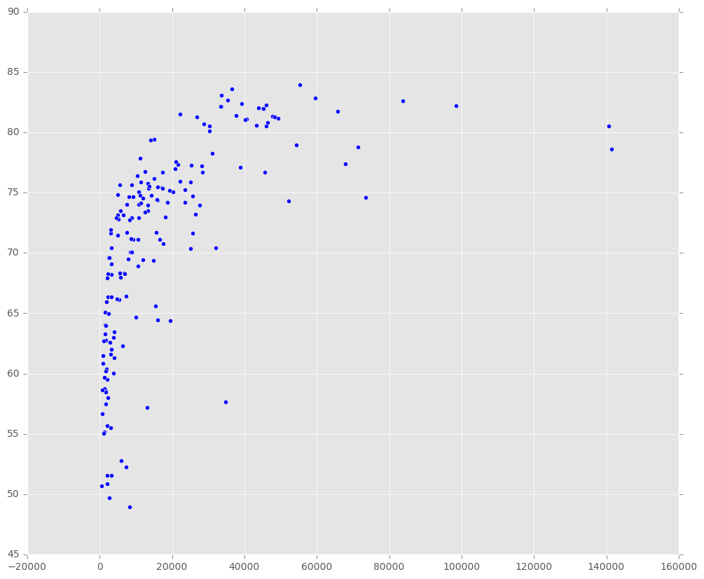

```python
plt.figure(figsize=(12, 10))
plt.scatter(x=lex_gdp_countries_df['2014_gdp'], y=lex_gdp_countries_df['2014_lex'])
```

- Now we'll add the population in the picture.
- The population data are available at http://data.worldbank.org/indicator/SP.POP.TOTL.
- We'll do the same drill, removing the last column.

```python
population_df = pd.read_csv('worldbank/population/API_SP.POP.TOTL_DS2_en_csv_v2.csv', skiprows=4)
population_df.drop(population_df.columns[len(population_df.columns) - 1], inplace=True, axis=1)
print(population_df.shape)
population_df
```

```
(264, 61)
```

|  | Country Name | Country Code | Indicator Name | Indicator Code | 1960 | 1961 | 1962 | 1963 | 1964 | 1965 | ... | 2007 | 2008 | 2009 | 2010 | 2011 | 2012 | 2013 | 2014 | 2015 | 2016 |
| --- | --- | --- | --- | --- | --- | --- | --- | --- | --- | --- | --- | --- | --- | --- | --- | --- | --- | --- | --- | --- | --- |
| 0 | Aruba | ABW | Population, total | SP.POP.TOTL | 5.420800e+04 | 5.543500e+04 | 5.622600e+04 | 5.669700e+04 | 5.702900e+04 | 5.736000e+04 | ... | 1.012180e+05 | 1.013420e+05 | 1.014160e+05 | 1.015970e+05 | 1.019360e+05 | 1.023930e+05 | 1.029210e+05 | 1.034410e+05 | 1.038890e+05 | NaN |
| 1 | Andorra | AND | Population, total | SP.POP.TOTL | 1.341400e+04 | 1.437600e+04 | 1.537600e+04 | 1.641000e+04 | 1.747000e+04 | 1.855100e+04 | ... | 8.487800e+04 | 8.561600e+04 | 8.547400e+04 | 8.441900e+04 | 8.232600e+04 | 7.931600e+04 | 7.590200e+04 | 7.278600e+04 | 7.047300e+04 | NaN |
| 2 | Afghanistan | AFG | Population, total | SP.POP.TOTL | 8.994793e+06 | 9.164945e+06 | 9.343772e+06 | 9.531555e+06 | 9.728645e+06 | 9.935358e+06 | ... | 2.587754e+07 | 2.652874e+07 | 2.720729e+07 | 2.796221e+07 | 2.880917e+07 | 2.972680e+07 | 3.068250e+07 | 3.162751e+07 | 3.252656e+07 | NaN |
| 3 | Angola | AGO | Population, total | SP.POP.TOTL | 5.270844e+06 | 5.367287e+06 | 5.465905e+06 | 5.565808e+06 | 5.665701e+06 | 5.765025e+06 | ... | 1.918391e+07 | 1.984225e+07 | 2.052010e+07 | 2.121995e+07 | 2.194230e+07 | 2.268563e+07 | 2.344820e+07 | 2.422752e+07 | 2.502197e+07 | NaN |
| 4 | Albania | ALB | Population, total | SP.POP.TOTL | 1.608800e+06 | 1.659800e+06 | 1.711319e+06 | 1.762621e+06 | 1.814135e+06 | 1.864791e+06 | ... | 2.970017e+06 | 2.947314e+06 | 2.927519e+06 | 2.913021e+06 | 2.904780e+06 | 2.900247e+06 | 2.896652e+06 | 2.893654e+06 | 2.889167e+06 | NaN |
| 5 | Arab World | ARB | Population, total | SP.POP.TOTL | 9.254053e+07 | 9.507799e+07 | 9.771119e+07 | 1.004394e+08 | 1.032637e+08 | 1.061841e+08 | ... | 3.287666e+08 | 3.368865e+08 | 3.450542e+08 | 3.531122e+08 | 3.610318e+08 | 3.688026e+08 | 3.765043e+08 | 3.842226e+08 | 3.920223e+08 | NaN |
| 6 | United Arab Emirates | ARE | Population, total | SP.POP.TOTL | 9.261200e+04 | 1.009850e+05 | 1.122400e+05 | 1.252160e+05 | 1.382200e+05 | 1.503180e+05 | ... | 6.010100e+06 | 6.900142e+06 | 7.705423e+06 | 8.329453e+06 | 8.734722e+06 | 8.952542e+06 | 9.039978e+06 | 9.086139e+06 | 9.156963e+06 | NaN |
| 7 | Argentina | ARG | Population, total | SP.POP.TOTL | 2.061908e+07 | 2.095308e+07 | 2.128768e+07 | 2.162184e+07 | 2.195393e+07 | 2.228339e+07 | ... | 3.996990e+07 | 4.038186e+07 | 4.079864e+07 | 4.122288e+07 | 4.165562e+07 | 4.209522e+07 | 4.253830e+07 | 4.298003e+07 | 4.341676e+07 | NaN |
| 8 | Armenia | ARM | Population, total | SP.POP.TOTL | 1.867396e+06 | 1.934239e+06 | 2.002170e+06 | 2.070427e+06 | 2.138133e+06 | 2.204650e+06 | ... | 2.988117e+06 | 2.975029e+06 | 2.966108e+06 | 2.963496e+06 | 2.967984e+06 | 2.978339e+06 | 2.992192e+06 | 3.006154e+06 | 3.017712e+06 | NaN |
| 9 | American Samoa | ASM | Population, total | SP.POP.TOTL | 2.001200e+04 | 2.047800e+04 | 2.111800e+04 | 2.188300e+04 | 2.270100e+04 | 2.351800e+04 | ... | 5.790400e+04 | 5.703100e+04 | 5.622600e+04 | 5.563600e+04 | 5.531600e+04 | 5.522700e+04 | 5.530200e+04 | 5.543400e+04 | 5.553800e+04 | NaN |
| 10 | Antigua and Barbuda | ATG | Population, total | SP.POP.TOTL | 5.468100e+04 | 5.540300e+04 | 5.631100e+04 | 5.736800e+04 | 5.850000e+04 | 5.965300e+04 | ... | 8.439700e+04 | 8.535000e+04 | 8.630000e+04 | 8.723300e+04 | 8.815200e+04 | 8.906900e+04 | 8.998500e+04 | 9.090000e+04 | 9.181800e+04 | NaN |
| 11 | Australia | AUS | Population, total | SP.POP.TOTL | 1.027648e+07 | 1.048300e+07 | 1.074200e+07 | 1.095000e+07 | 1.116700e+07 | 1.138800e+07 | ... | 2.082760e+07 | 2.124920e+07 | 2.169170e+07 | 2.203175e+07 | 2.234002e+07 | 2.272825e+07 | 2.311735e+07 | 2.346409e+07 | 2.378117e+07 | NaN |
| 12 | Austria | AUT | Population, total | SP.POP.TOTL | 7.047539e+06 | 7.086299e+06 | 7.129864e+06 | 7.175811e+06 | 7.223801e+06 | 7.270889e+06 | ... | 8.295487e+06 | 8.321496e+06 | 8.343323e+06 | 8.363404e+06 | 8.391643e+06 | 8.429991e+06 | 8.479375e+06 | 8.541575e+06 | 8.611088e+06 | NaN |
| 13 | Azerbaijan | AZE | Population, total | SP.POP.TOTL | 3.897889e+06 | 4.030130e+06 | 4.167558e+06 | 4.307315e+06 | 4.445653e+06 | 4.579759e+06 | ... | 8.581300e+06 | 8.763400e+06 | 8.947243e+06 | 9.054332e+06 | 9.173082e+06 | 9.295784e+06 | 9.416801e+06 | 9.535079e+06 | 9.651349e+06 | NaN |
| 14 | Burundi | BDI | Population, total | SP.POP.TOTL | 2.786740e+06 | 2.840375e+06 | 2.894510e+06 | 2.950903e+06 | 3.011957e+06 | 3.079034e+06 | ... | 8.514578e+06 | 8.821795e+06 | 9.137786e+06 | 9.461117e+06 | 9.790151e+06 | 1.012457e+07 | 1.046596e+07 | 1.081686e+07 | 1.117892e+07 | NaN |
| 15 | Belgium | BEL | Population, total | SP.POP.TOTL | 9.153489e+06 | 9.183948e+06 | 9.220578e+06 | 9.289770e+06 | 9.378113e+06 | 9.463667e+06 | ... | 1.062570e+07 | 1.070997e+07 | 1.079649e+07 | 1.089559e+07 | 1.104774e+07 | 1.112825e+07 | 1.118282e+07 | 1.123121e+07 | 1.128572e+07 | NaN |
| 16 | Benin | BEN | Population, total | SP.POP.TOTL | 2.431620e+06 | 2.466002e+06 | 2.503232e+06 | 2.543335e+06 | 2.586362e+06 | 2.632360e+06 | ... | 8.707637e+06 | 8.973525e+06 | 9.240982e+06 | 9.509798e+06 | 9.779391e+06 | 1.004979e+07 | 1.032223e+07 | 1.059848e+07 | 1.087983e+07 | NaN |
| 17 | Burkina Faso | BFA | Population, total | SP.POP.TOTL | 4.829291e+06 | 4.894578e+06 | 4.960325e+06 | 5.027818e+06 | 5.098892e+06 | 5.174869e+06 | ... | 1.426400e+07 | 1.470901e+07 | 1.516586e+07 | 1.563207e+07 | 1.610685e+07 | 1.659081e+07 | 1.708455e+07 | 1.758920e+07 | 1.810557e+07 | NaN |
| 18 | Bangladesh | BGD | Population, total | SP.POP.TOTL | 4.820070e+07 | 4.959361e+07 | 5.103060e+07 | 5.253260e+07 | 5.412939e+07 | 5.583502e+07 | ... | 1.465927e+08 | 1.482525e+08 | 1.499058e+08 | 1.516168e+08 | 1.534056e+08 | 1.552574e+08 | 1.571574e+08 | 1.590775e+08 | 1.609956e+08 | NaN |
| 19 | Bulgaria | BGR | Population, total | SP.POP.TOTL | 7.867374e+06 | 7.943118e+06 | 8.012946e+06 | 8.078145e+06 | 8.144340e+06 | 8.204168e+06 | ... | 7.545338e+06 | 7.492561e+06 | 7.444443e+06 | 7.395599e+06 | 7.348328e+06 | 7.305888e+06 | 7.265115e+06 | 7.223938e+06 | 7.177991e+06 | NaN |
| 20 | Bahrain | BHR | Population, total | SP.POP.TOTL | 1.625010e+05 | 1.679240e+05 | 1.731070e+05 | 1.780480e+05 | 1.827740e+05 | 1.873480e+05 | ... | 1.026568e+06 | 1.115777e+06 | 1.196774e+06 | 1.261319e+06 | 1.306014e+06 | 1.333577e+06 | 1.349427e+06 | 1.361930e+06 | 1.377237e+06 | NaN |
| 21 | Bahamas, The | BHS | Population, total | SP.POP.TOTL | 1.095260e+05 | 1.151080e+05 | 1.210830e+05 | 1.273310e+05 | 1.336970e+05 | 1.400490e+05 | ... | 3.422590e+05 | 3.485870e+05 | 3.547800e+05 | 3.608300e+05 | 3.667110e+05 | 3.723880e+05 | 3.778410e+05 | 3.830540e+05 | 3.880190e+05 | NaN |
| 22 | Bosnia and Herzegovina | BIH | Population, total | SP.POP.TOTL | 3.214520e+06 | 3.277096e+06 | 3.341809e+06 | 3.406466e+06 | 3.468083e+06 | 3.524596e+06 | ... | 3.840418e+06 | 3.839749e+06 | 3.837732e+06 | 3.835258e+06 | 3.832310e+06 | 3.828419e+06 | 3.823533e+06 | 3.817554e+06 | 3.810416e+06 | NaN |
| 23 | Belarus | BLR | Population, total | SP.POP.TOTL | 8.198000e+06 | 8.271216e+06 | 8.351928e+06 | 8.437232e+06 | 8.524224e+06 | 8.610000e+06 | ... | 9.560000e+06 | 9.528000e+06 | 9.507000e+06 | 9.490000e+06 | 9.473000e+06 | 9.464000e+06 | 9.466000e+06 | 9.483000e+06 | 9.513000e+06 | NaN |
| 24 | Belize | BLZ | Population, total | SP.POP.TOTL | 9.206800e+04 | 9.470100e+04 | 9.738900e+04 | 1.001660e+05 | 1.030700e+05 | 1.061210e+05 | ... | 2.984030e+05 | 3.061650e+05 | 3.139250e+05 | 3.216090e+05 | 3.291930e+05 | 3.367070e+05 | 3.441930e+05 | 3.517060e+05 | 3.592870e+05 | NaN |
| 25 | Bermuda | BMU | Population, total | SP.POP.TOTL | 4.440000e+04 | 4.550000e+04 | 4.660000e+04 | 4.770000e+04 | 4.890000e+04 | 5.010000e+04 | ... | 6.488800e+04 | 6.527300e+04 | 6.563600e+04 | 6.512400e+04 | 6.456400e+04 | 6.479800e+04 | 6.500100e+04 | 6.513900e+04 | 6.523500e+04 | NaN |
| 26 | Bolivia | BOL | Population, total | SP.POP.TOTL | 3.693451e+06 | 3.764815e+06 | 3.838096e+06 | 3.913397e+06 | 3.990855e+06 | 4.070590e+06 | ... | 9.441482e+06 | 9.599916e+06 | 9.758799e+06 | 9.918245e+06 | 1.007824e+07 | 1.023876e+07 | 1.039993e+07 | 1.056189e+07 | 1.072470e+07 | NaN |
| 27 | Brazil | BRA | Population, total | SP.POP.TOTL | 7.249358e+07 | 7.470689e+07 | 7.700755e+07 | 7.936845e+07 | 8.175180e+07 | 8.413006e+07 | ... | 1.927845e+08 | 1.947697e+08 | 1.967013e+08 | 1.986142e+08 | 2.005176e+08 | 2.024016e+08 | 2.042594e+08 | 2.060779e+08 | 2.078475e+08 | NaN |
| 28 | Barbados | BRB | Population, total | SP.POP.TOTL | 2.309340e+05 | 2.316740e+05 | 2.325840e+05 | 2.335870e+05 | 2.345470e+05 | 2.353730e+05 | ... | 2.761540e+05 | 2.773150e+05 | 2.784660e+05 | 2.795660e+05 | 2.806020e+05 | 2.815800e+05 | 2.825030e+05 | 2.833800e+05 | 2.842150e+05 | NaN |
| 29 | Brunei Darussalam | BRN | Population, total | SP.POP.TOTL | 8.182500e+04 | 8.568700e+04 | 8.960300e+04 | 9.365000e+04 | 9.793300e+04 | 1.025250e+05 | ... | 3.744590e+05 | 3.807860e+05 | 3.870800e+05 | 3.933020e+05 | 3.994430e+05 | 4.055120e+05 | 4.114990e+05 | 4.173940e+05 | 4.231880e+05 | NaN |
| ... | ... | ... | ... | ... | ... | ... | ... | ... | ... | ... | ... | ... | ... | ... | ... | ... | ... | ... | ... | ... | ... |
| 234 | Middle East & North Africa (IDA & IBRD countries) | TMN | Population, total | SP.POP.TOTL | 9.791405e+07 | 1.005201e+08 | 1.032034e+08 | 1.059679e+08 | 1.088222e+08 | 1.117711e+08 | ... | 3.110368e+08 | 3.166325e+08 | 3.223389e+08 | 3.281177e+08 | 3.339812e+08 | 3.398933e+08 | 3.458872e+08 | 3.519682e+08 | 3.581388e+08 | NaN |
| 235 | Timor-Leste | TLS | Population, total | SP.POP.TOTL | 4.995250e+05 | 5.083110e+05 | 5.174460e+05 | 5.269360e+05 | 5.367980e+05 | 5.470350e+05 | ... | 1.013194e+06 | 1.030630e+06 | 1.048367e+06 | 1.066409e+06 | 1.120392e+06 | 1.148958e+06 | 1.180069e+06 | 1.212107e+06 | 1.245015e+06 | NaN |
| 236 | Tonga | TON | Population, total | SP.POP.TOTL | 6.160000e+04 | 6.374000e+04 | 6.625500e+04 | 6.900000e+04 | 7.175700e+04 | 7.436300e+04 | ... | 1.021690e+05 | 1.028160e+05 | 1.034160e+05 | 1.039470e+05 | 1.043920e+05 | 1.047690e+05 | 1.051390e+05 | 1.055860e+05 | 1.061700e+05 | NaN |
| 237 | South Asia (IDA & IBRD) | TSA | Population, total | SP.POP.TOTL | 5.720361e+08 | 5.841432e+08 | 5.967011e+08 | 6.095715e+08 | 6.230731e+08 | 6.369638e+08 | ... | 1.558686e+09 | 1.582147e+09 | 1.605444e+09 | 1.628689e+09 | 1.651889e+09 | 1.675019e+09 | 1.698093e+09 | 1.721153e+09 | 1.744161e+09 | NaN |
| 238 | Sub-Saharan Africa (IDA & IBRD countries) | TSS | Population, total | SP.POP.TOTL | 2.282688e+08 | 2.337600e+08 | 2.394036e+08 | 2.452170e+08 | 2.512159e+08 | 2.574149e+08 | ... | 8.049504e+08 | 8.272397e+08 | 8.501903e+08 | 8.737802e+08 | 8.979985e+08 | 9.228551e+08 | 9.483224e+08 | 9.743719e+08 | 1.000981e+09 | NaN |
| 239 | Trinidad and Tobago | TTO | Population, total | SP.POP.TOTL | 8.484810e+05 | 8.653560e+05 | 8.800190e+05 | 8.925710e+05 | 9.032720e+05 | 9.124190e+05 | ... | 1.309260e+06 | 1.315372e+06 | 1.321624e+06 | 1.328095e+06 | 1.334790e+06 | 1.341579e+06 | 1.348240e+06 | 1.354483e+06 | 1.360088e+06 | NaN |
| 240 | Tunisia | TUN | Population, total | SP.POP.TOTL | 4.220701e+06 | 4.277371e+06 | 4.350811e+06 | 4.436643e+06 | 4.530835e+06 | 4.630000e+06 | ... | 1.022510e+07 | 1.032890e+07 | 1.043960e+07 | 1.054710e+07 | 1.067380e+07 | 1.077750e+07 | 1.088650e+07 | 1.099660e+07 | 1.110780e+07 | NaN |
| 241 | Turkey | TUR | Population, total | SP.POP.TOTL | 2.755328e+07 | 2.822929e+07 | 2.890998e+07 | 2.959705e+07 | 3.029297e+07 | 3.100017e+07 | ... | 6.951549e+07 | 7.034436e+07 | 7.126131e+07 | 7.231042e+07 | 7.351700e+07 | 7.484919e+07 | 7.622364e+07 | 7.752379e+07 | 7.866583e+07 | NaN |
| 242 | Tuvalu | TUV | Population, total | SP.POP.TOTL | 6.104000e+03 | 6.242000e+03 | 6.391000e+03 | 6.542000e+03 | 6.687000e+03 | 6.819000e+03 | ... | 9.764000e+03 | 9.788000e+03 | 9.808000e+03 | 9.827000e+03 | 9.844000e+03 | 9.860000e+03 | 9.876000e+03 | 9.893000e+03 | 9.916000e+03 | NaN |
| 243 | Tanzania | TZA | Population, total | SP.POP.TOTL | 1.007449e+07 | 1.037338e+07 | 1.068389e+07 | 1.100588e+07 | 1.133908e+07 | 1.168351e+07 | ... | 4.152200e+07 | 4.284474e+07 | 4.422211e+07 | 4.564852e+07 | 4.712300e+07 | 4.864571e+07 | 5.021346e+07 | 5.182262e+07 | 5.347042e+07 | NaN |
| 244 | Uganda | UGA | Population, total | SP.POP.TOTL | 6.788211e+06 | 7.006629e+06 | 7.240155e+06 | 7.487411e+06 | 7.746181e+06 | 8.014376e+06 | ... | 2.999196e+07 | 3.101443e+07 | 3.206712e+07 | 3.314942e+07 | 3.426034e+07 | 3.540062e+07 | 3.657339e+07 | 3.778297e+07 | 3.903238e+07 | NaN |
| 245 | Ukraine | UKR | Population, total | SP.POP.TOTL | 4.266215e+07 | 4.320364e+07 | 4.374947e+07 | 4.428590e+07 | 4.479432e+07 | 4.526194e+07 | ... | 4.650935e+07 | 4.625820e+07 | 4.605330e+07 | 4.587070e+07 | 4.570610e+07 | 4.559330e+07 | 4.548960e+07 | 4.536290e+07 | 4.519820e+07 | NaN |
| 246 | Upper middle income | UMC | Population, total | SP.POP.TOTL | 1.175211e+09 | 1.180098e+09 | 1.197381e+09 | 1.225994e+09 | 1.254220e+09 | 1.283353e+09 | ... | 2.437537e+09 | 2.455687e+09 | 2.474451e+09 | 2.493277e+09 | 2.512627e+09 | 2.532681e+09 | 2.553112e+09 | 2.573612e+09 | 2.593743e+09 | NaN |
| 247 | Uruguay | URY | Population, total | SP.POP.TOTL | 2.538651e+06 | 2.571691e+06 | 2.603887e+06 | 2.635128e+06 | 2.665387e+06 | 2.694535e+06 | ... | 3.339750e+06 | 3.350832e+06 | 3.362761e+06 | 3.374414e+06 | 3.385610e+06 | 3.396753e+06 | 3.407969e+06 | 3.419516e+06 | 3.431555e+06 | NaN |
| 248 | United States | USA | Population, total | SP.POP.TOTL | 1.806710e+08 | 1.836910e+08 | 1.865380e+08 | 1.892420e+08 | 1.918890e+08 | 1.943030e+08 | ... | 3.012312e+08 | 3.040940e+08 | 3.067715e+08 | 3.093469e+08 | 3.117189e+08 | 3.141026e+08 | 3.164274e+08 | 3.189074e+08 | 3.214188e+08 | NaN |
| 249 | Uzbekistan | UZB | Population, total | SP.POP.TOTL | 8.789492e+06 | 9.044671e+06 | 9.319510e+06 | 9.611601e+06 | 9.917202e+06 | 1.023350e+07 | ... | 2.686800e+07 | 2.730280e+07 | 2.776740e+07 | 2.856240e+07 | 2.933940e+07 | 2.977450e+07 | 3.024320e+07 | 3.075770e+07 | 3.129950e+07 | NaN |
| 250 | St. Vincent and the Grenadines | VCT | Population, total | SP.POP.TOTL | 8.094800e+04 | 8.214400e+04 | 8.320600e+04 | 8.416700e+04 | 8.507600e+04 | 8.597200e+04 | ... | 1.090490e+05 | 1.091650e+05 | 1.092550e+05 | 1.093160e+05 | 1.093410e+05 | 1.093340e+05 | 1.093270e+05 | 1.093600e+05 | 1.094620e+05 | NaN |
| 251 | Venezuela, RB | VEN | Population, total | SP.POP.TOTL | 8.146845e+06 | 8.461684e+06 | 8.790590e+06 | 9.130346e+06 | 9.476255e+06 | 9.824694e+06 | ... | 2.767066e+07 | 2.811672e+07 | 2.855861e+07 | 2.899574e+07 | 2.942763e+07 | 2.985424e+07 | 3.027604e+07 | 3.069383e+07 | 3.110808e+07 | NaN |
| 252 | British Virgin Islands | VGB | Population, total | SP.POP.TOTL | 8.036000e+03 | 8.157000e+03 | 8.298000e+03 | 8.455000e+03 | 8.628000e+03 | 8.813000e+03 | ... | 2.473500e+04 | 2.560400e+04 | 2.645000e+04 | 2.722300e+04 | 2.790600e+04 | 2.851100e+04 | 2.905800e+04 | 2.958500e+04 | 3.011700e+04 | NaN |
| 253 | Virgin Islands (U.S.) | VIR | Population, total | SP.POP.TOTL | 3.200000e+04 | 3.410000e+04 | 3.630000e+04 | 3.870000e+04 | 4.130000e+04 | 4.400000e+04 | ... | 1.074230e+05 | 1.070910e+05 | 1.067070e+05 | 1.062670e+05 | 1.057840e+05 | 1.052750e+05 | 1.047370e+05 | 1.041700e+05 | 1.035740e+05 | NaN |
| 254 | Vietnam | VNM | Population, total | SP.POP.TOTL | 3.474300e+07 | 3.542800e+07 | 3.612300e+07 | 3.683600e+07 | 3.757400e+07 | 3.834100e+07 | ... | 8.421850e+07 | 8.511870e+07 | 8.602500e+07 | 8.693250e+07 | 8.786030e+07 | 8.880920e+07 | 8.975950e+07 | 9.072890e+07 | 9.170380e+07 | NaN |
| 255 | Vanuatu | VUT | Population, total | SP.POP.TOTL | 6.370100e+04 | 6.570800e+04 | 6.780600e+04 | 6.996200e+04 | 7.213100e+04 | 7.428700e+04 | ... | 2.199560e+05 | 2.253350e+05 | 2.307820e+05 | 2.362990e+05 | 2.418760e+05 | 2.474980e+05 | 2.531650e+05 | 2.588830e+05 | 2.646520e+05 | NaN |
| 256 | West Bank and Gaza | PSE | Population, total | SP.POP.TOTL | NaN | NaN | NaN | NaN | NaN | NaN | ... | 3.494496e+06 | 3.596688e+06 | 3.702218e+06 | 3.811102e+06 | 3.927051e+06 | 4.046901e+06 | 4.169506e+06 | 4.294682e+06 | 4.422143e+06 | NaN |
| 257 | World | WLD | Population, total | SP.POP.TOTL | 3.035056e+09 | 3.076121e+09 | 3.129064e+09 | 3.193947e+09 | 3.259355e+09 | 3.326054e+09 | ... | 6.675833e+09 | 6.758303e+09 | 6.840956e+09 | 6.923684e+09 | 7.006908e+09 | 7.089452e+09 | 7.176092e+09 | 7.260780e+09 | 7.346633e+09 | NaN |
| 258 | Samoa | WSM | Population, total | SP.POP.TOTL | 1.086450e+05 | 1.121210e+05 | 1.157860e+05 | 1.195640e+05 | 1.233540e+05 | 1.270680e+05 | ... | 1.822380e+05 | 1.834400e+05 | 1.847000e+05 | 1.860290e+05 | 1.874340e+05 | 1.889010e+05 | 1.903900e+05 | 1.918450e+05 | 1.932280e+05 | NaN |
| 259 | Yemen, Rep. | YEM | Population, total | SP.POP.TOTL | 5.166311e+06 | 5.251663e+06 | 5.339285e+06 | 5.429501e+06 | 5.522690e+06 | 5.619170e+06 | ... | 2.170110e+07 | 2.232270e+07 | 2.295423e+07 | 2.359197e+07 | 2.423494e+07 | 2.488279e+07 | 2.553322e+07 | 2.618368e+07 | 2.683222e+07 | NaN |
| 260 | South Africa | ZAF | Population, total | SP.POP.TOTL | 1.739600e+07 | 1.794996e+07 | 1.845944e+07 | 1.893614e+07 | 1.939055e+07 | 1.983200e+07 | ... | 4.859678e+07 | 4.929622e+07 | 5.002092e+07 | 5.077183e+07 | 5.154996e+07 | 5.235638e+07 | 5.319222e+07 | 5.405865e+07 | 5.495692e+07 | NaN |
| 261 | Congo, Dem. Rep. | COD | Population, total | SP.POP.TOTL | 1.524825e+07 | 1.563772e+07 | 1.604125e+07 | 1.646191e+07 | 1.690390e+07 | 1.736986e+07 | ... | 5.983488e+07 | 6.180928e+07 | 6.384510e+07 | 6.593871e+07 | 6.808738e+07 | 7.029116e+07 | 7.255286e+07 | 7.487703e+07 | 7.726681e+07 | NaN |
| 262 | Zambia | ZMB | Population, total | SP.POP.TOTL | 3.049586e+06 | 3.142848e+06 | 3.240664e+06 | 3.342894e+06 | 3.449266e+06 | 3.559687e+06 | ... | 1.273868e+07 | 1.311458e+07 | 1.350785e+07 | 1.391744e+07 | 1.434353e+07 | 1.478658e+07 | 1.524609e+07 | 1.572134e+07 | 1.621177e+07 | NaN |
| 263 | Zimbabwe | ZWE | Population, total | SP.POP.TOTL | 3.752390e+06 | 3.876638e+06 | 4.006262e+06 | 4.140804e+06 | 4.279561e+06 | 4.422132e+06 | ... | 1.329780e+07 | 1.349546e+07 | 1.372100e+07 | 1.397390e+07 | 1.425559e+07 | 1.456548e+07 | 1.489809e+07 | 1.524586e+07 | 1.560275e+07 | NaN |

264 rows × 61 columns

- Now we'll join the GDP dataframe with the population dataframe.
- Again, the join will be perfomed on the `Country Code` column and we will provide our own suffixes to make them easier to understand.

```python
pop_lex_gdp_countries_df = pd.merge(lex_gdp_countries_df,
                                    population_df,
                                    how="inner",
                                    on="Country Code",
                                    suffixes=("gpd", "pop"))
print(pop_lex_gdp_countries_df.shape)
pop_lex_gdp_countries_df
```

```
(217, 181)
```

|  | Country Namegpd | Country Code | Indicator Name_gdp | Indicator Code_gdp | 1960_gdp | 1961_gdp | 1962_gdp | 1963_gdp | 1964_gdp | 1965_gdp | ... | 2007 | 2008 | 2009 | 2010 | 2011 | 2012 | 2013 | 2014 | 2015 | 2016 |
| --- | --- | --- | --- | --- | --- | --- | --- | --- | --- | --- | --- | --- | --- | --- | --- | --- | --- | --- | --- | --- | --- |
| 0 | Aruba | ABW | GDP per capita, PPP (current international $) | NY.GDP.PCAP.PP.CD | NaN | NaN | NaN | NaN | NaN | NaN | ... | 101218.0 | 101342.0 | 101416.0 | 101597.0 | 101936.0 | 102393.0 | 102921.0 | 103441.0 | 103889.0 | NaN |
| 1 | Andorra | AND | GDP per capita, PPP (current international $) | NY.GDP.PCAP.PP.CD | NaN | NaN | NaN | NaN | NaN | NaN | ... | 84878.0 | 85616.0 | 85474.0 | 84419.0 | 82326.0 | 79316.0 | 75902.0 | 72786.0 | 70473.0 | NaN |
| 2 | Afghanistan | AFG | GDP per capita, PPP (current international $) | NY.GDP.PCAP.PP.CD | NaN | NaN | NaN | NaN | NaN | NaN | ... | 25877544.0 | 26528741.0 | 27207291.0 | 27962207.0 | 28809167.0 | 29726803.0 | 30682500.0 | 31627506.0 | 32526562.0 | NaN |
| 3 | Angola | AGO | GDP per capita, PPP (current international $) | NY.GDP.PCAP.PP.CD | NaN | NaN | NaN | NaN | NaN | NaN | ... | 19183907.0 | 19842251.0 | 20520103.0 | 21219954.0 | 21942296.0 | 22685632.0 | 23448202.0 | 24227524.0 | 25021974.0 | NaN |
| 4 | Albania | ALB | GDP per capita, PPP (current international $) | NY.GDP.PCAP.PP.CD | NaN | NaN | NaN | NaN | NaN | NaN | ... | 2970017.0 | 2947314.0 | 2927519.0 | 2913021.0 | 2904780.0 | 2900247.0 | 2896652.0 | 2893654.0 | 2889167.0 | NaN |
| 5 | United Arab Emirates | ARE | GDP per capita, PPP (current international $) | NY.GDP.PCAP.PP.CD | NaN | NaN | NaN | NaN | NaN | NaN | ... | 6010100.0 | 6900142.0 | 7705423.0 | 8329453.0 | 8734722.0 | 8952542.0 | 9039978.0 | 9086139.0 | 9156963.0 | NaN |
| 6 | Argentina | ARG | GDP per capita, PPP (current international $) | NY.GDP.PCAP.PP.CD | NaN | NaN | NaN | NaN | NaN | NaN | ... | 39969903.0 | 40381860.0 | 40798641.0 | 41222875.0 | 41655616.0 | 42095224.0 | 42538304.0 | 42980026.0 | 43416755.0 | NaN |
| 7 | Armenia | ARM | GDP per capita, PPP (current international $) | NY.GDP.PCAP.PP.CD | NaN | NaN | NaN | NaN | NaN | NaN | ... | 2988117.0 | 2975029.0 | 2966108.0 | 2963496.0 | 2967984.0 | 2978339.0 | 2992192.0 | 3006154.0 | 3017712.0 | NaN |
| 8 | American Samoa | ASM | GDP per capita, PPP (current international $) | NY.GDP.PCAP.PP.CD | NaN | NaN | NaN | NaN | NaN | NaN | ... | 57904.0 | 57031.0 | 56226.0 | 55636.0 | 55316.0 | 55227.0 | 55302.0 | 55434.0 | 55538.0 | NaN |
| 9 | Antigua and Barbuda | ATG | GDP per capita, PPP (current international $) | NY.GDP.PCAP.PP.CD | NaN | NaN | NaN | NaN | NaN | NaN | ... | 84397.0 | 85350.0 | 86300.0 | 87233.0 | 88152.0 | 89069.0 | 89985.0 | 90900.0 | 91818.0 | NaN |
| 10 | Australia | AUS | GDP per capita, PPP (current international $) | NY.GDP.PCAP.PP.CD | NaN | NaN | NaN | NaN | NaN | NaN | ... | 20827600.0 | 21249200.0 | 21691700.0 | 22031750.0 | 22340024.0 | 22728254.0 | 23117353.0 | 23464086.0 | 23781169.0 | NaN |
| 11 | Austria | AUT | GDP per capita, PPP (current international $) | NY.GDP.PCAP.PP.CD | NaN | NaN | NaN | NaN | NaN | NaN | ... | 8295487.0 | 8321496.0 | 8343323.0 | 8363404.0 | 8391643.0 | 8429991.0 | 8479375.0 | 8541575.0 | 8611088.0 | NaN |
| 12 | Azerbaijan | AZE | GDP per capita, PPP (current international $) | NY.GDP.PCAP.PP.CD | NaN | NaN | NaN | NaN | NaN | NaN | ... | 8581300.0 | 8763400.0 | 8947243.0 | 9054332.0 | 9173082.0 | 9295784.0 | 9416801.0 | 9535079.0 | 9651349.0 | NaN |
| 13 | Burundi | BDI | GDP per capita, PPP (current international $) | NY.GDP.PCAP.PP.CD | NaN | NaN | NaN | NaN | NaN | NaN | ... | 8514578.0 | 8821795.0 | 9137786.0 | 9461117.0 | 9790151.0 | 10124572.0 | 10465959.0 | 10816860.0 | 11178921.0 | NaN |
| 14 | Belgium | BEL | GDP per capita, PPP (current international $) | NY.GDP.PCAP.PP.CD | NaN | NaN | NaN | NaN | NaN | NaN | ... | 10625700.0 | 10709973.0 | 10796493.0 | 10895586.0 | 11047744.0 | 11128246.0 | 11182817.0 | 11231213.0 | 11285721.0 | NaN |
| 15 | Benin | BEN | GDP per capita, PPP (current international $) | NY.GDP.PCAP.PP.CD | NaN | NaN | NaN | NaN | NaN | NaN | ... | 8707637.0 | 8973525.0 | 9240982.0 | 9509798.0 | 9779391.0 | 10049792.0 | 10322232.0 | 10598482.0 | 10879829.0 | NaN |
| 16 | Burkina Faso | BFA | GDP per capita, PPP (current international $) | NY.GDP.PCAP.PP.CD | NaN | NaN | NaN | NaN | NaN | NaN | ... | 14264002.0 | 14709011.0 | 15165856.0 | 15632066.0 | 16106851.0 | 16590813.0 | 17084554.0 | 17589198.0 | 18105570.0 | NaN |
| 17 | Bangladesh | BGD | GDP per capita, PPP (current international $) | NY.GDP.PCAP.PP.CD | NaN | NaN | NaN | NaN | NaN | NaN | ... | 146592687.0 | 148252473.0 | 149905836.0 | 151616777.0 | 153405612.0 | 155257387.0 | 157157394.0 | 159077513.0 | 160995642.0 | NaN |
| 18 | Bulgaria | BGR | GDP per capita, PPP (current international $) | NY.GDP.PCAP.PP.CD | NaN | NaN | NaN | NaN | NaN | NaN | ... | 7545338.0 | 7492561.0 | 7444443.0 | 7395599.0 | 7348328.0 | 7305888.0 | 7265115.0 | 7223938.0 | 7177991.0 | NaN |
| 19 | Bahrain | BHR | GDP per capita, PPP (current international $) | NY.GDP.PCAP.PP.CD | NaN | NaN | NaN | NaN | NaN | NaN | ... | 1026568.0 | 1115777.0 | 1196774.0 | 1261319.0 | 1306014.0 | 1333577.0 | 1349427.0 | 1361930.0 | 1377237.0 | NaN |
| 20 | Bahamas, The | BHS | GDP per capita, PPP (current international $) | NY.GDP.PCAP.PP.CD | NaN | NaN | NaN | NaN | NaN | NaN | ... | 342259.0 | 348587.0 | 354780.0 | 360830.0 | 366711.0 | 372388.0 | 377841.0 | 383054.0 | 388019.0 | NaN |
| 21 | Bosnia and Herzegovina | BIH | GDP per capita, PPP (current international $) | NY.GDP.PCAP.PP.CD | NaN | NaN | NaN | NaN | NaN | NaN | ... | 3840418.0 | 3839749.0 | 3837732.0 | 3835258.0 | 3832310.0 | 3828419.0 | 3823533.0 | 3817554.0 | 3810416.0 | NaN |
| 22 | Belarus | BLR | GDP per capita, PPP (current international $) | NY.GDP.PCAP.PP.CD | NaN | NaN | NaN | NaN | NaN | NaN | ... | 9560000.0 | 9528000.0 | 9507000.0 | 9490000.0 | 9473000.0 | 9464000.0 | 9466000.0 | 9483000.0 | 9513000.0 | NaN |
| 23 | Belize | BLZ | GDP per capita, PPP (current international $) | NY.GDP.PCAP.PP.CD | NaN | NaN | NaN | NaN | NaN | NaN | ... | 298403.0 | 306165.0 | 313925.0 | 321609.0 | 329193.0 | 336707.0 | 344193.0 | 351706.0 | 359287.0 | NaN |
| 24 | Bermuda | BMU | GDP per capita, PPP (current international $) | NY.GDP.PCAP.PP.CD | NaN | NaN | NaN | NaN | NaN | NaN | ... | 64888.0 | 65273.0 | 65636.0 | 65124.0 | 64564.0 | 64798.0 | 65001.0 | 65139.0 | 65235.0 | NaN |
| 25 | Bolivia | BOL | GDP per capita, PPP (current international $) | NY.GDP.PCAP.PP.CD | NaN | NaN | NaN | NaN | NaN | NaN | ... | 9441482.0 | 9599916.0 | 9758799.0 | 9918245.0 | 10078238.0 | 10238762.0 | 10399931.0 | 10561887.0 | 10724705.0 | NaN |
| 26 | Brazil | BRA | GDP per capita, PPP (current international $) | NY.GDP.PCAP.PP.CD | NaN | NaN | NaN | NaN | NaN | NaN | ... | 192784521.0 | 194769696.0 | 196701298.0 | 198614208.0 | 200517584.0 | 202401584.0 | 204259377.0 | 206077898.0 | 207847528.0 | NaN |
| 27 | Barbados | BRB | GDP per capita, PPP (current international $) | NY.GDP.PCAP.PP.CD | NaN | NaN | NaN | NaN | NaN | NaN | ... | 276154.0 | 277315.0 | 278466.0 | 279566.0 | 280602.0 | 281580.0 | 282503.0 | 283380.0 | 284215.0 | NaN |
| 28 | Brunei Darussalam | BRN | GDP per capita, PPP (current international $) | NY.GDP.PCAP.PP.CD | NaN | NaN | NaN | NaN | NaN | NaN | ... | 374459.0 | 380786.0 | 387080.0 | 393302.0 | 399443.0 | 405512.0 | 411499.0 | 417394.0 | 423188.0 | NaN |
| 29 | Bhutan | BTN | GDP per capita, PPP (current international $) | NY.GDP.PCAP.PP.CD | NaN | NaN | NaN | NaN | NaN | NaN | ... | 681471.0 | 694990.0 | 707830.0 | 720246.0 | 732246.0 | 743711.0 | 754637.0 | 765008.0 | 774830.0 | NaN |
| ... | ... | ... | ... | ... | ... | ... | ... | ... | ... | ... | ... | ... | ... | ... | ... | ... | ... | ... | ... | ... | ... |
| 187 | Chad | TCD | GDP per capita, PPP (current international $) | NY.GDP.PCAP.PP.CD | NaN | NaN | NaN | NaN | NaN | NaN | ... | 10779504.0 | 11139740.0 | 11510535.0 | 11896380.0 | 12298512.0 | 12715465.0 | 13145788.0 | 13587053.0 | 14037472.0 | NaN |
| 188 | Togo | TGO | GDP per capita, PPP (current international $) | NY.GDP.PCAP.PP.CD | NaN | NaN | NaN | NaN | NaN | NaN | ... | 5890414.0 | 6052937.0 | 6219761.0 | 6390851.0 | 6566179.0 | 6745581.0 | 6928719.0 | 7115163.0 | 7304578.0 | NaN |
| 189 | Thailand | THA | GDP per capita, PPP (current international $) | NY.GDP.PCAP.PP.CD | NaN | NaN | NaN | NaN | NaN | NaN | ... | 66353572.0 | 66453255.0 | 66548197.0 | 66692024.0 | 66902958.0 | 67164130.0 | 67451422.0 | 67725979.0 | 67959359.0 | NaN |
| 190 | Tajikistan | TJK | GDP per capita, PPP (current international $) | NY.GDP.PCAP.PP.CD | NaN | NaN | NaN | NaN | NaN | NaN | ... | 7099021.0 | 7254072.0 | 7414960.0 | 7581696.0 | 7753925.0 | 7930929.0 | 8111894.0 | 8295840.0 | 8481855.0 | NaN |
| 191 | Turkmenistan | TKM | GDP per capita, PPP (current international $) | NY.GDP.PCAP.PP.CD | NaN | NaN | NaN | NaN | NaN | NaN | ... | 4858235.0 | 4917541.0 | 4978960.0 | 5041995.0 | 5106672.0 | 5172941.0 | 5240088.0 | 5307188.0 | 5373502.0 | NaN |
| 192 | Timor-Leste | TLS | GDP per capita, PPP (current international $) | NY.GDP.PCAP.PP.CD | NaN | NaN | NaN | NaN | NaN | NaN | ... | 1013194.0 | 1030630.0 | 1048367.0 | 1066409.0 | 1120392.0 | 1148958.0 | 1180069.0 | 1212107.0 | 1245015.0 | NaN |
| 193 | Tonga | TON | GDP per capita, PPP (current international $) | NY.GDP.PCAP.PP.CD | NaN | NaN | NaN | NaN | NaN | NaN | ... | 102169.0 | 102816.0 | 103416.0 | 103947.0 | 104392.0 | 104769.0 | 105139.0 | 105586.0 | 106170.0 | NaN |
| 194 | Trinidad and Tobago | TTO | GDP per capita, PPP (current international $) | NY.GDP.PCAP.PP.CD | NaN | NaN | NaN | NaN | NaN | NaN | ... | 1309260.0 | 1315372.0 | 1321624.0 | 1328095.0 | 1334790.0 | 1341579.0 | 1348240.0 | 1354483.0 | 1360088.0 | NaN |
| 195 | Tunisia | TUN | GDP per capita, PPP (current international $) | NY.GDP.PCAP.PP.CD | NaN | NaN | NaN | NaN | NaN | NaN | ... | 10225100.0 | 10328900.0 | 10439600.0 | 10547100.0 | 10673800.0 | 10777500.0 | 10886500.0 | 10996600.0 | 11107800.0 | NaN |
| 196 | Turkey | TUR | GDP per capita, PPP (current international $) | NY.GDP.PCAP.PP.CD | NaN | NaN | NaN | NaN | NaN | NaN | ... | 69515492.0 | 70344357.0 | 71261307.0 | 72310416.0 | 73517002.0 | 74849187.0 | 76223639.0 | 77523788.0 | 78665830.0 | NaN |
| 197 | Tuvalu | TUV | GDP per capita, PPP (current international $) | NY.GDP.PCAP.PP.CD | NaN | NaN | NaN | NaN | NaN | NaN | ... | 9764.0 | 9788.0 | 9808.0 | 9827.0 | 9844.0 | 9860.0 | 9876.0 | 9893.0 | 9916.0 | NaN |
| 198 | Tanzania | TZA | GDP per capita, PPP (current international $) | NY.GDP.PCAP.PP.CD | NaN | NaN | NaN | NaN | NaN | NaN | ... | 41522004.0 | 42844744.0 | 44222113.0 | 45648525.0 | 47122998.0 | 48645709.0 | 50213457.0 | 51822621.0 | 53470420.0 | NaN |
| 199 | Uganda | UGA | GDP per capita, PPP (current international $) | NY.GDP.PCAP.PP.CD | NaN | NaN | NaN | NaN | NaN | NaN | ... | 29991958.0 | 31014427.0 | 32067125.0 | 33149417.0 | 34260342.0 | 35400620.0 | 36573387.0 | 37782971.0 | 39032383.0 | NaN |
| 200 | Ukraine | UKR | GDP per capita, PPP (current international $) | NY.GDP.PCAP.PP.CD | NaN | NaN | NaN | NaN | NaN | NaN | ... | 46509350.0 | 46258200.0 | 46053300.0 | 45870700.0 | 45706100.0 | 45593300.0 | 45489600.0 | 45362900.0 | 45198200.0 | NaN |
| 201 | Uruguay | URY | GDP per capita, PPP (current international $) | NY.GDP.PCAP.PP.CD | NaN | NaN | NaN | NaN | NaN | NaN | ... | 3339750.0 | 3350832.0 | 3362761.0 | 3374414.0 | 3385610.0 | 3396753.0 | 3407969.0 | 3419516.0 | 3431555.0 | NaN |
| 202 | United States | USA | GDP per capita, PPP (current international $) | NY.GDP.PCAP.PP.CD | NaN | NaN | NaN | NaN | NaN | NaN | ... | 301231207.0 | 304093966.0 | 306771529.0 | 309346863.0 | 311718857.0 | 314102623.0 | 316427395.0 | 318907401.0 | 321418820.0 | NaN |
| 203 | Uzbekistan | UZB | GDP per capita, PPP (current international $) | NY.GDP.PCAP.PP.CD | NaN | NaN | NaN | NaN | NaN | NaN | ... | 26868000.0 | 27302800.0 | 27767400.0 | 28562400.0 | 29339400.0 | 29774500.0 | 30243200.0 | 30757700.0 | 31299500.0 | NaN |
| 204 | St. Vincent and the Grenadines | VCT | GDP per capita, PPP (current international $) | NY.GDP.PCAP.PP.CD | NaN | NaN | NaN | NaN | NaN | NaN | ... | 109049.0 | 109165.0 | 109255.0 | 109316.0 | 109341.0 | 109334.0 | 109327.0 | 109360.0 | 109462.0 | NaN |
| 205 | Venezuela, RB | VEN | GDP per capita, PPP (current international $) | NY.GDP.PCAP.PP.CD | NaN | NaN | NaN | NaN | NaN | NaN | ... | 27670659.0 | 28116716.0 | 28558607.0 | 28995745.0 | 29427631.0 | 29854238.0 | 30276045.0 | 30693827.0 | 31108083.0 | NaN |
| 206 | British Virgin Islands | VGB | GDP per capita, PPP (current international $) | NY.GDP.PCAP.PP.CD | NaN | NaN | NaN | NaN | NaN | NaN | ... | 24735.0 | 25604.0 | 26450.0 | 27223.0 | 27906.0 | 28511.0 | 29058.0 | 29585.0 | 30117.0 | NaN |
| 207 | Virgin Islands (U.S.) | VIR | GDP per capita, PPP (current international $) | NY.GDP.PCAP.PP.CD | NaN | NaN | NaN | NaN | NaN | NaN | ... | 107423.0 | 107091.0 | 106707.0 | 106267.0 | 105784.0 | 105275.0 | 104737.0 | 104170.0 | 103574.0 | NaN |
| 208 | Vietnam | VNM | GDP per capita, PPP (current international $) | NY.GDP.PCAP.PP.CD | NaN | NaN | NaN | NaN | NaN | NaN | ... | 84218500.0 | 85118700.0 | 86025000.0 | 86932500.0 | 87860300.0 | 88809200.0 | 89759500.0 | 90728900.0 | 91703800.0 | NaN |
| 209 | Vanuatu | VUT | GDP per capita, PPP (current international $) | NY.GDP.PCAP.PP.CD | NaN | NaN | NaN | NaN | NaN | NaN | ... | 219956.0 | 225335.0 | 230782.0 | 236299.0 | 241876.0 | 247498.0 | 253165.0 | 258883.0 | 264652.0 | NaN |
| 210 | West Bank and Gaza | PSE | GDP per capita, PPP (current international $) | NY.GDP.PCAP.PP.CD | NaN | NaN | NaN | NaN | NaN | NaN | ... | 3494496.0 | 3596688.0 | 3702218.0 | 3811102.0 | 3927051.0 | 4046901.0 | 4169506.0 | 4294682.0 | 4422143.0 | NaN |
| 211 | Samoa | WSM | GDP per capita, PPP (current international $) | NY.GDP.PCAP.PP.CD | NaN | NaN | NaN | NaN | NaN | NaN | ... | 182238.0 | 183440.0 | 184700.0 | 186029.0 | 187434.0 | 188901.0 | 190390.0 | 191845.0 | 193228.0 | NaN |
| 212 | Yemen, Rep. | YEM | GDP per capita, PPP (current international $) | NY.GDP.PCAP.PP.CD | NaN | NaN | NaN | NaN | NaN | NaN | ... | 21701105.0 | 22322699.0 | 22954226.0 | 23591972.0 | 24234940.0 | 24882792.0 | 25533217.0 | 26183676.0 | 26832215.0 | NaN |
| 213 | South Africa | ZAF | GDP per capita, PPP (current international $) | NY.GDP.PCAP.PP.CD | NaN | NaN | NaN | NaN | NaN | NaN | ... | 48596781.0 | 49296223.0 | 50020918.0 | 50771826.0 | 51549958.0 | 52356381.0 | 53192216.0 | 54058647.0 | 54956920.0 | NaN |
| 214 | Congo, Dem. Rep. | COD | GDP per capita, PPP (current international $) | NY.GDP.PCAP.PP.CD | NaN | NaN | NaN | NaN | NaN | NaN | ... | 59834875.0 | 61809278.0 | 63845097.0 | 65938712.0 | 68087376.0 | 70291160.0 | 72552861.0 | 74877030.0 | 77266814.0 | NaN |
| 215 | Zambia | ZMB | GDP per capita, PPP (current international $) | NY.GDP.PCAP.PP.CD | NaN | NaN | NaN | NaN | NaN | NaN | ... | 12738676.0 | 13114579.0 | 13507849.0 | 13917439.0 | 14343526.0 | 14786581.0 | 15246086.0 | 15721343.0 | 16211767.0 | NaN |
| 216 | Zimbabwe | ZWE | GDP per capita, PPP (current international $) | NY.GDP.PCAP.PP.CD | NaN | NaN | NaN | NaN | NaN | NaN | ... | 13297798.0 | 13495462.0 | 13720997.0 | 13973897.0 | 14255592.0 | 14565482.0 | 14898092.0 | 15245855.0 | 15602751.0 | NaN |

217 rows × 181 columns

- Let's see how the scatter plot looks like now.

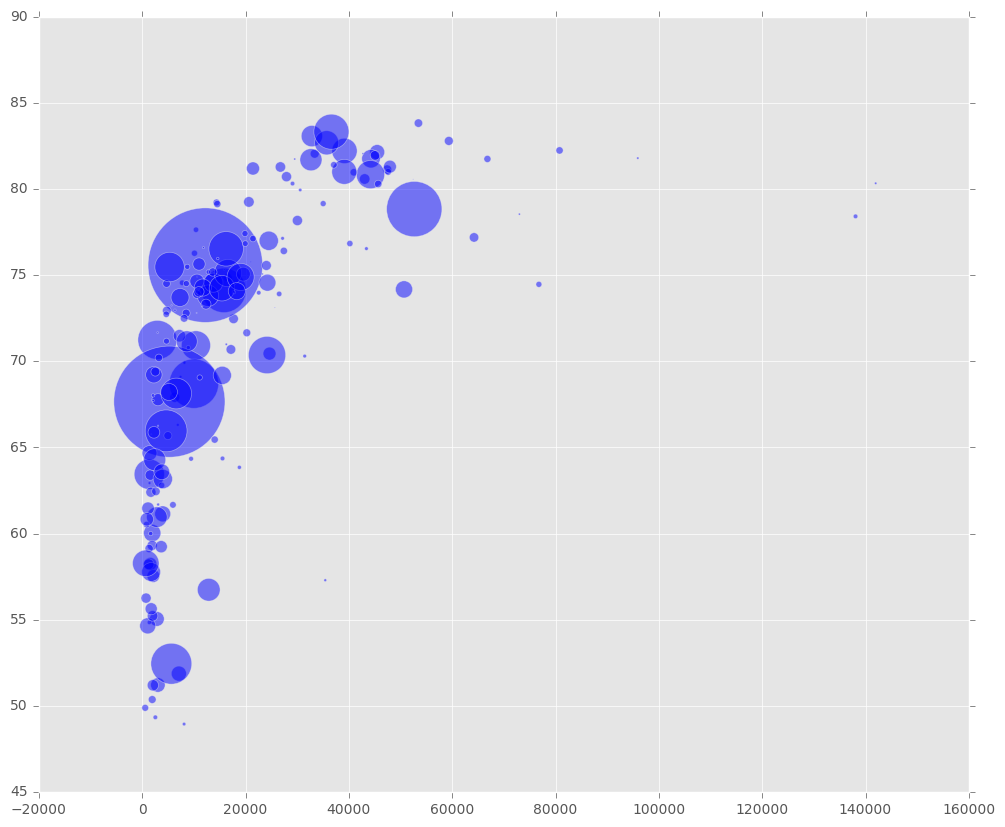

```python
plt.figure(figsize=(12, 10))
plt.scatter(x=pop_lex_gdp_countries_df['2013_gdp'],
            y=pop_lex_gdp_countries_df['2013_lex'],
            s=0.000005*pop_lex_gdp_countries_df['2013'],
            alpha=0.5)
```

- The previous graph can be improved.
- We can change the labels on the x axis to show thousands.
- More importantly, we can change the x axis to run on a logarithmic scale.

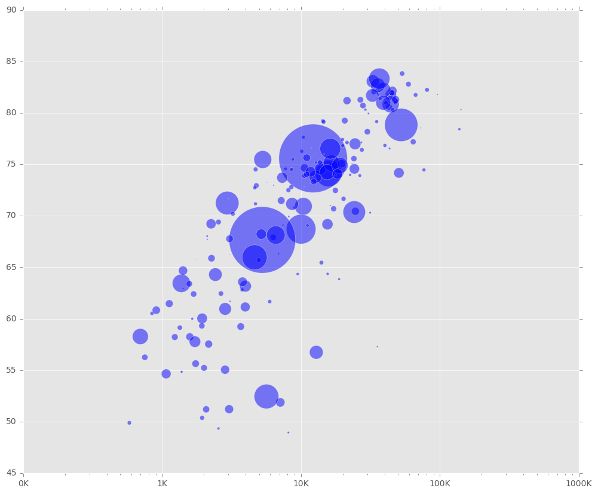

```python
from matplotlib.ticker import FuncFormatter

plt.figure(figsize=(12, 10))
plt.scatter(x=pop_lex_gdp_countries_df['2013_gdp'],
            y=pop_lex_gdp_countries_df['2013_lex'],
            s=0.000005*pop_lex_gdp_countries_df['2013'],
            alpha=0.5)
plt.xscale("log")

formatter = FuncFormatter(lambda v, p: "%dK" % (v / 1000))

plt.gca().xaxis.set_major_formatter(formatter)
```

- As a further improvement, we would like to group the data based on the region of each country.
- To do that, first we'll get a list of the regions and we'll create a region mapping from region names to integer values.

```python
regions = pop_lex_gdp_countries_df['Region'].drop_duplicates()
print(regions)
regions_map = {v: k for k, v in enumerate(regions)}
print(regions_map)
```

```
0      Latin America & Caribbean
1          Europe & Central Asia
2                     South Asia
3             Sub-Saharan Africa
5     Middle East & North Africa
8            East Asia & Pacific
24                 North America
Name: Region, dtype: object
{'North America': 6, 'Sub-Saharan Africa': 3, 'Europe & Central Asia': 1, 'South Asia': 2, 'Latin America & Caribbean': 0, 'East Asia & Pacific': 5, 'Middle East & North Africa': 4}
```

- We'll use the region mapping to add a `Region Code` column in our dataset.

```python
pop_lex_gdp_countries_df['Region Code'] = pop_lex_gdp_countries_df['Region'].map(regions_map)
region_codes = pop_lex_gdp_countries_df['Region Code'].drop_duplicates()
print(region_codes)
```

```
0     0
1     1
2     2
3     3
5     4
8     5
24    6
Name: Region Code, dtype: int64
```

- Now we can create a plot that includes the region information, as a color dimension.
- Note that we have to create the legend manually.
- That's because we plotted everything in one go.
- If we would like to have the legend created automatically, we should plot each region separately.

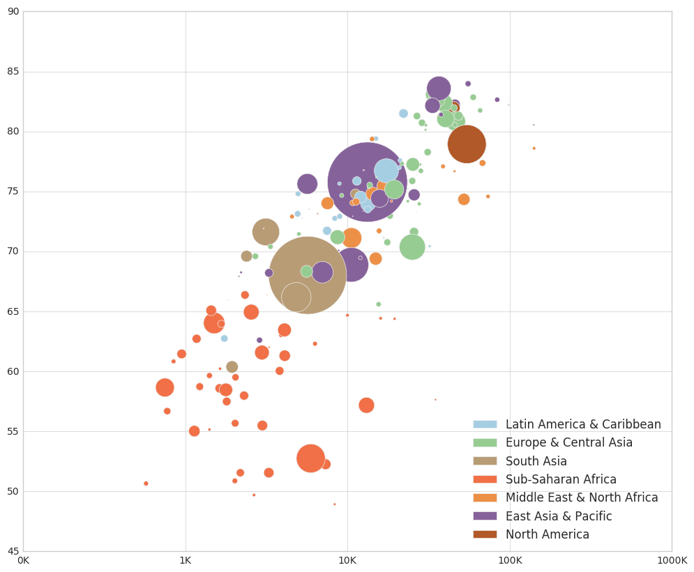

```python
import matplotlib.patches as mpatches
import matplotlib.colors
import matplotlib.ticker

plt.style.use('seaborn-whitegrid')


plt.figure(figsize=(12, 10))
plt.scatter(x=pop_lex_gdp_countries_df['2014_gdp'],
            y=pop_lex_gdp_countries_df['2014_lex'],
            s=0.000005*pop_lex_gdp_countries_df['2014'],
            c=pop_lex_gdp_countries_df['Region Code'],
            alpha=1,
            cmap='Paired')

plt.xscale("log")

recs = []

cmap = plt.get_cmap('Paired')

norm = matplotlib.colors.Normalize(0.0, 6.0)
for rc in region_codes:
    recs.append(mpatches.Rectangle((0,0),1,1,
                                   fc=cmap(norm(rc))))
plt.legend(recs, regions, loc='lower right')
plt.gca().xaxis.set_major_formatter(formatter)
```